# Assignment 1 - a22mohmo

### Loading packages into R

```r
library(forecast)
library(tsutils)
```

### Loading data into R

```r
Y <- read.csv("./workshop1R.csv")
```

## Exercises

I have furnished my observational summaries at the conclusion of each time series analysis, culminating in comprehensive responses to the exercise questions collectively.

### Level_A - Time Series

#### Load Data

```r
y <- Y[,1]
print(y)
```

```
##  [1] 309.5927 285.0966 298.8200 284.3028 308.5171 306.8993 325.4628 326.9226
##  [9] 302.5102 319.5777 332.5051 342.4510 339.0753 334.1232 361.4546 336.1173
## [17] 319.6460 317.3951 328.0461 304.5760 355.3091 330.1500 342.8376 327.5952
## [25] 328.0343 322.7103 329.1623 312.8083 319.9644 310.1535 338.1874 314.8126
## [33] 345.3493 313.4708 304.8354 311.6021 307.4285 347.2009 326.6501 308.4443
## [41] 299.1128 341.9722 302.1470 295.1502 351.9557 332.8738 324.6155 306.7664
## [49] 320.3624 350.8271 317.0764 300.9870 336.8473 316.1264 321.9198 336.2565
## [57] 335.7531 332.0578 324.6613 352.9658
```

```r
y <- ts(y,frequency=12,end=c(2018,11))
print(y)
```

```
##           Jan      Feb      Mar      Apr      May      Jun      Jul      Aug
## 2013
## 2014 285.0966 298.8200 284.3028 308.5171 306.8993 325.4628 326.9226 302.5102
## 2015 334.1232 361.4546 336.1173 319.6460 317.3951 328.0461 304.5760 355.3091
## 2016 322.7103 329.1623 312.8083 319.9644 310.1535 338.1874 314.8126 345.3493
## 2017 347.2009 326.6501 308.4443 299.1128 341.9722 302.1470 295.1502 351.9557
## 2018 350.8271 317.0764 300.9870 336.8473 316.1264 321.9198 336.2565 335.7531
##           Sep      Oct      Nov      Dec
## 2013                            309.5927
## 2014 319.5777 332.5051 342.4510 339.0753
## 2015 330.1500 342.8376 327.5952 328.0343
## 2016 313.4708 304.8354 311.6021 307.4285
## 2017 332.8738 324.6155 306.7664 320.3624
## 2018 332.0578 324.6613 352.9658
```

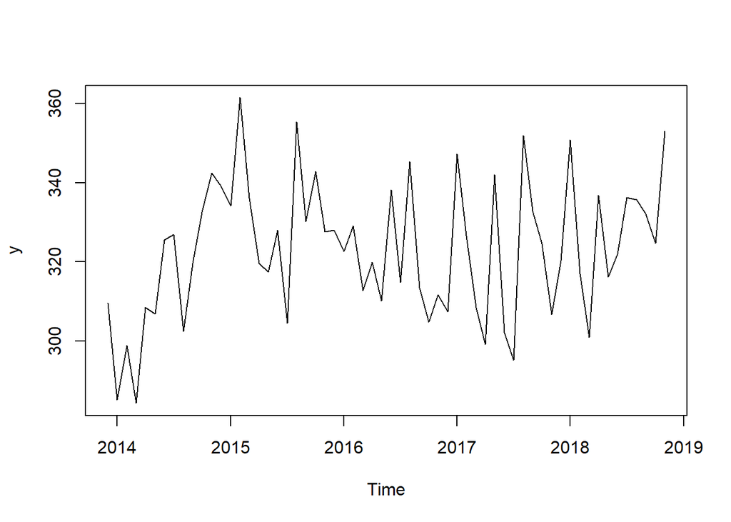

```r
plot(y)
```

#### Constructing estimation and hold-out sets

```r
y.tst <- tail(y,12)
y.trn <- head(y,48)
```

#### Verifying Data

```r
yy <- y[1:48]
print(yy)
```

```
##  [1] 309.5927 285.0966 298.8200 284.3028 308.5171 306.8993 325.4628 326.9226
##  [9] 302.5102 319.5777 332.5051 342.4510 339.0753 334.1232 361.4546 336.1173
## [17] 319.6460 317.3951 328.0461 304.5760 355.3091 330.1500 342.8376 327.5952
## [25] 328.0343 322.7103 329.1623 312.8083 319.9644 310.1535 338.1874 314.8126
## [33] 345.3493 313.4708 304.8354 311.6021 307.4285 347.2009 326.6501 308.4443
## [41] 299.1128 341.9722 302.1470 295.1502 351.9557 332.8738 324.6155 306.7664
```

```r
class(y) # Our time series object
```

```
## [1] "ts"
```

```r
class(yy) # A simple vector of numeric values
```

```
## [1] "numeric"
```

```r
yy == y.trn
```

```
##       Jan  Feb  Mar  Apr  May  Jun  Jul  Aug  Sep  Oct  Nov  Dec
## 2013                                                        TRUE
## 2014 TRUE TRUE TRUE TRUE TRUE TRUE TRUE TRUE TRUE TRUE TRUE TRUE
## 2015 TRUE TRUE TRUE TRUE TRUE TRUE TRUE TRUE TRUE TRUE TRUE TRUE
## 2016 TRUE TRUE TRUE TRUE TRUE TRUE TRUE TRUE TRUE TRUE TRUE TRUE
## 2017 TRUE TRUE TRUE TRUE TRUE TRUE TRUE TRUE TRUE TRUE TRUE
```

```r
all(yy==y.trn)
```

```
## [1] TRUE
```

#### Exploration

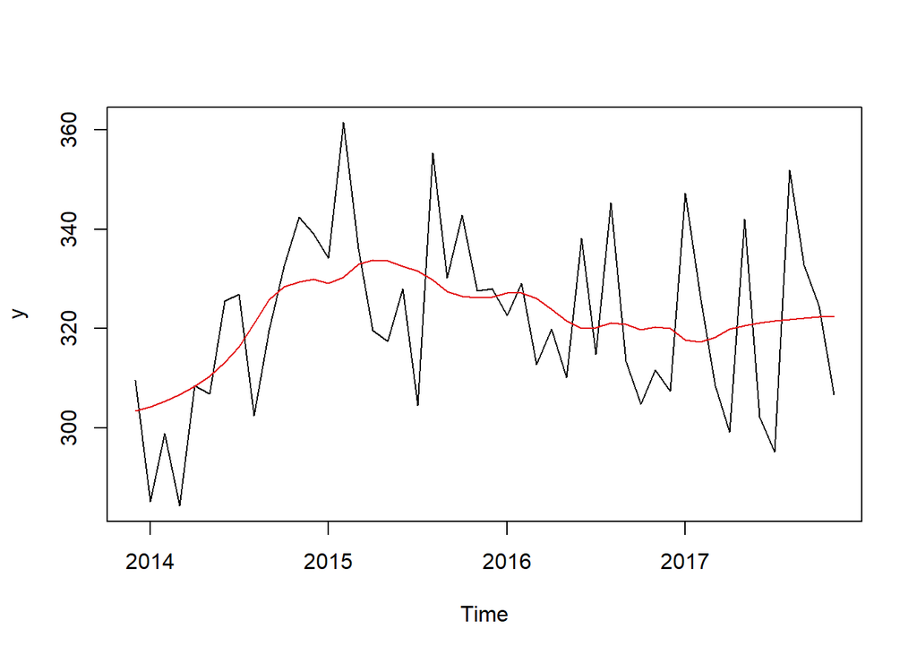

```r
cma <- cmav(y.trn,outplot=1)
```

```r
print(cma)
```

```
##           Jan      Feb      Mar      Apr      May      Jun      Jul      Aug
## 2013
## 2014 304.2395 305.3201 306.6708 308.3591 310.4696 313.1166 316.3878 321.0404
## 2015 329.0542 330.3231 332.9636 333.8346 333.6461 332.5671 331.6315 329.8105
## 2016 327.2172 327.2288 326.1188 323.8404 321.5906 320.0656 320.2275 321.1433
## 2017 317.7662 317.2222 318.3059 319.9386 320.5613 321.0955 321.5123 321.8458
##           Sep      Oct      Nov      Dec
## 2013                            303.3751
## 2014 325.8091 328.4317 329.3328 329.8777
## 2015 327.4937 326.5358 326.2473 326.3682
## 2016 320.8568 319.8061 320.2631 320.0872
## 2017 322.1126 322.3260 322.4968
```

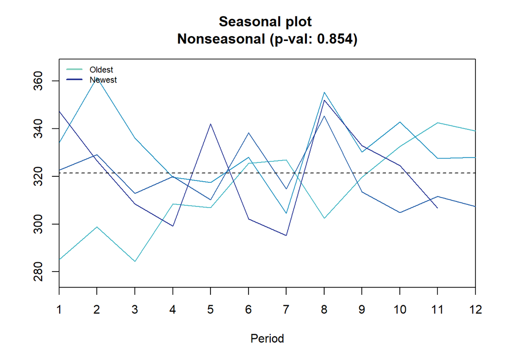

```
## Results of statistical testing
## Evidence of trend: FALSE  (pval: 0.154)
## Evidence of seasonality: FALSE  (pval: 0.854)
```

```r
seasplot(y.trn)
```

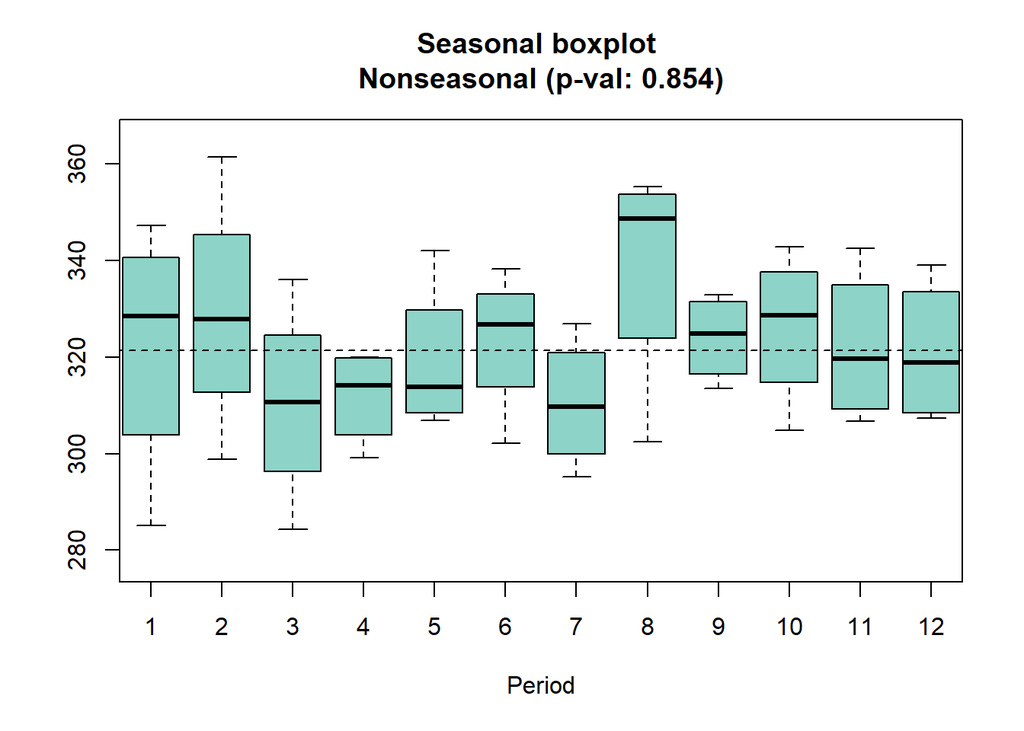

```
## Results of statistical testing
## Evidence of trend: FALSE  (pval: 0.154)
## Evidence of seasonality: FALSE  (pval: 0.854)
```

```r
seasplot(y.trn,outplot=2)
```

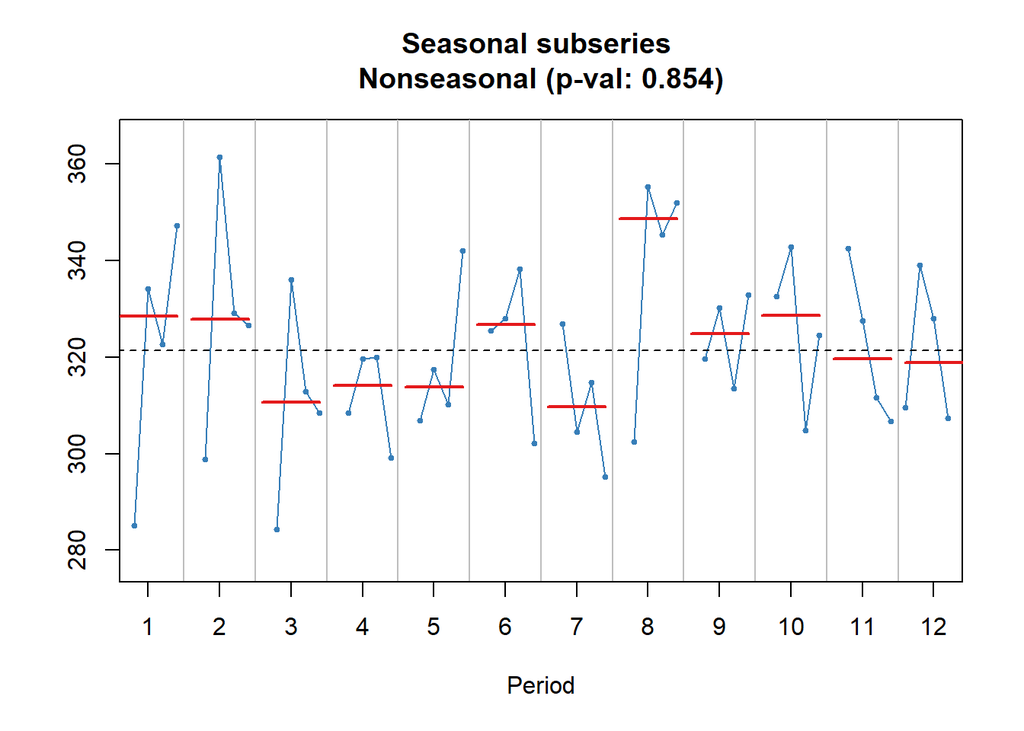

```
## Results of statistical testing
## Evidence of trend: FALSE  (pval: 0.154)
## Evidence of seasonality: FALSE  (pval: 0.854)
```

```r
seasplot(y.trn,outplot=3)
```

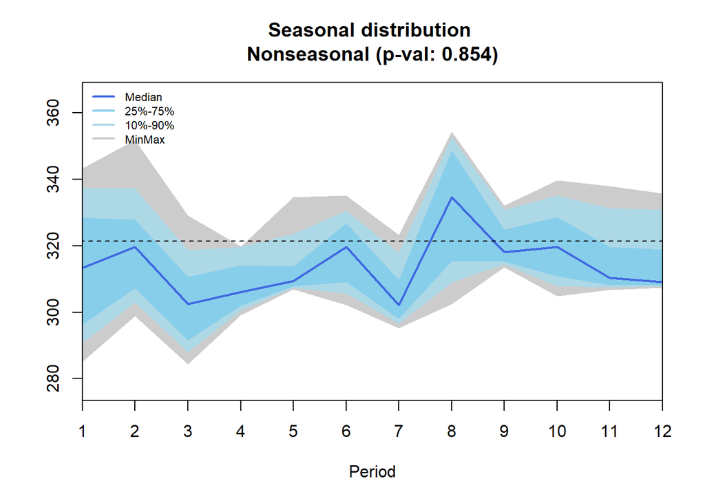

```
## Results of statistical testing
## Evidence of trend: FALSE  (pval: 0.154)
## Evidence of seasonality: FALSE  (pval: 0.854)
```

```r
seasplot(y.trn,outplot=4)
```

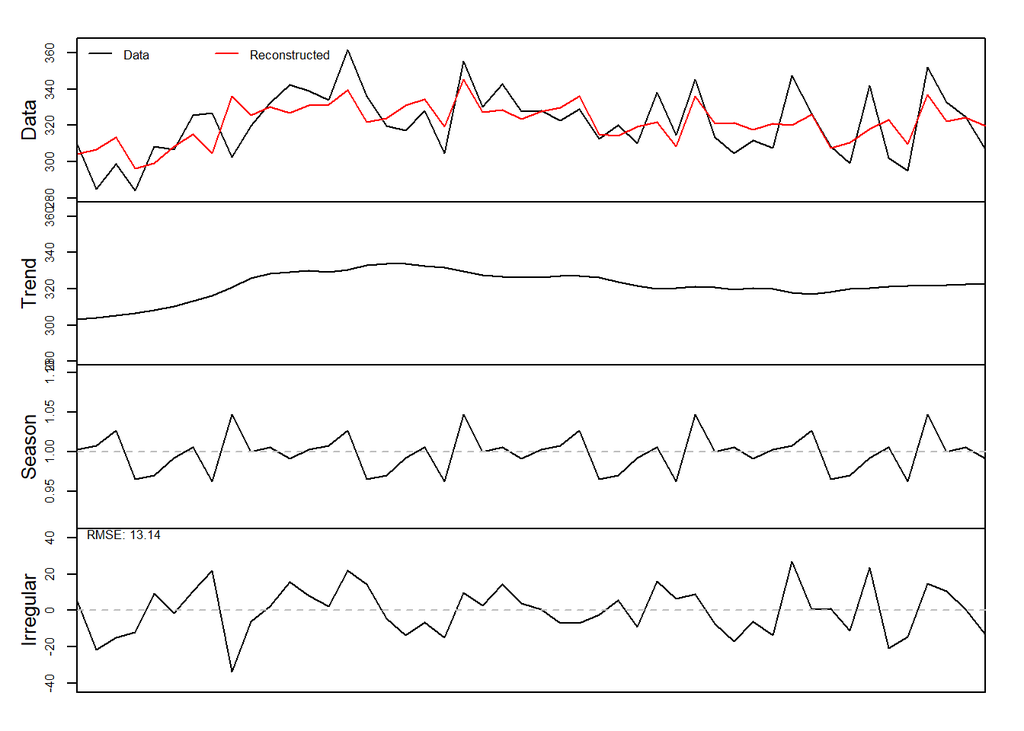

```r
dc <- decomp(y.trn,outplot=1)
```

#### Observation

- **Trend Analysis:** A thorough examination of the data reveals the absence of any discernible trend. This observation is further substantiated by the visualization graphs, which clearly indicate the absence of both upward and downward trends in the dataset.
- **Seasonality Assessment:** A meticulous statistical analysis also confirms the absence of seasonality within the dataset. The accompanying visualization graphs corroborate this finding by demonstrating the absence of any repetitive patterns that would typically be indicative of seasonality.
- **Conclusion:** In summary, analysis unequivocally concludes that neither trend nor seasonality is evident in this time series data.

### Level_B -Time Series

#### Load Data

```r
y <- Y[,2]
print(y)
```

```
##  [1] 484.7822 494.9082 478.1126 479.0342 489.2530 502.9581 475.7626 481.5800
##  [9] 518.7196 468.4896 467.0762 487.6958 482.6020 458.8387 505.8385 457.3302
## [17] 480.6295 463.1917 515.9150 487.7321 501.9705 475.2583 526.4980 442.9300
## [25] 499.9444 510.9078 518.4830 470.6329 484.1704 471.2600 489.2770 490.8059
## [33] 493.5122 491.7161 505.7463 528.2059 509.4413 503.8770 486.3193 483.7063
## [41] 504.0208 500.8155 538.5808 486.6391 517.4006 503.0216 451.8103 502.4365
## [49] 504.7120 495.3900 493.6047 505.4475 499.1231 504.4805 483.0237 511.3350
## [57] 502.4504 511.9520 498.7966 531.7996
```

```r
y <- ts(y,frequency=12,end=c(2018,11))
print(y)
```

```
##           Jan      Feb      Mar      Apr      May      Jun      Jul      Aug
## 2013
## 2014 494.9082 478.1126 479.0342 489.2530 502.9581 475.7626 481.5800 518.7196
## 2015 458.8387 505.8385 457.3302 480.6295 463.1917 515.9150 487.7321 501.9705
## 2016 510.9078 518.4830 470.6329 484.1704 471.2600 489.2770 490.8059 493.5122
## 2017 503.8770 486.3193 483.7063 504.0208 500.8155 538.5808 486.6391 517.4006
## 2018 495.3900 493.6047 505.4475 499.1231 504.4805 483.0237 511.3350 502.4504
##           Sep      Oct      Nov      Dec
## 2013                            484.7822
## 2014 468.4896 467.0762 487.6958 482.6020
## 2015 475.2583 526.4980 442.9300 499.9444
## 2016 491.7161 505.7463 528.2059 509.4413
## 2017 503.0216 451.8103 502.4365 504.7120
## 2018 511.9520 498.7966 531.7996
```

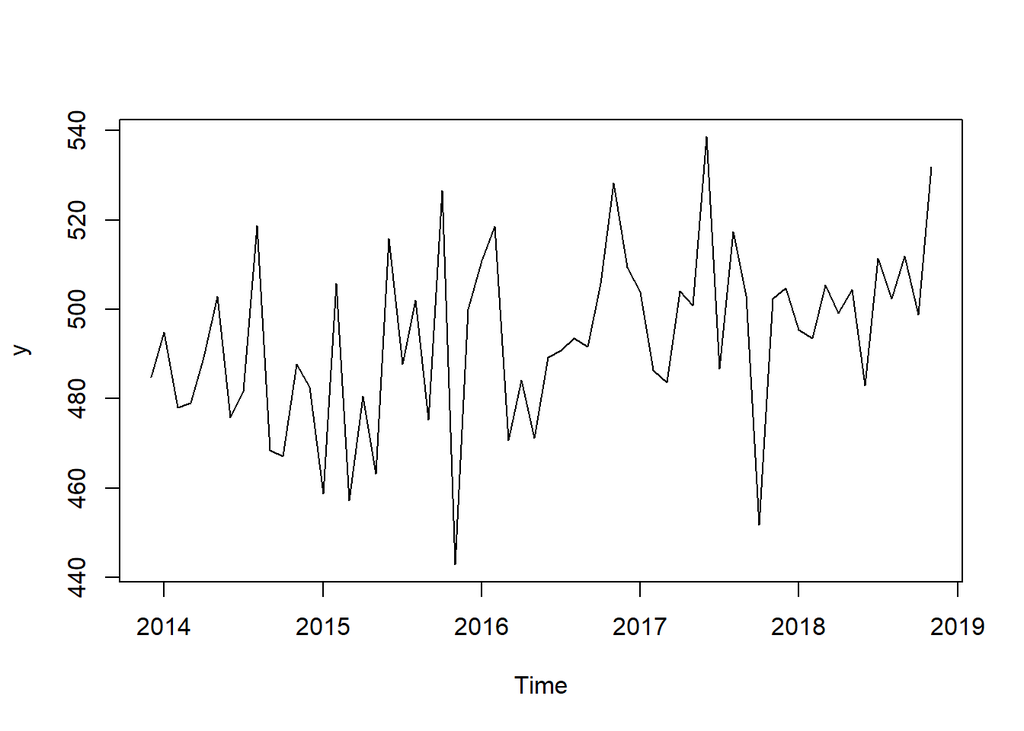

```r
plot(y)
```

#### Constructing estimation and hold-out sets

```r
y.tst <- tail(y,12)
y.trn <- head(y,48)
```

#### Exploration

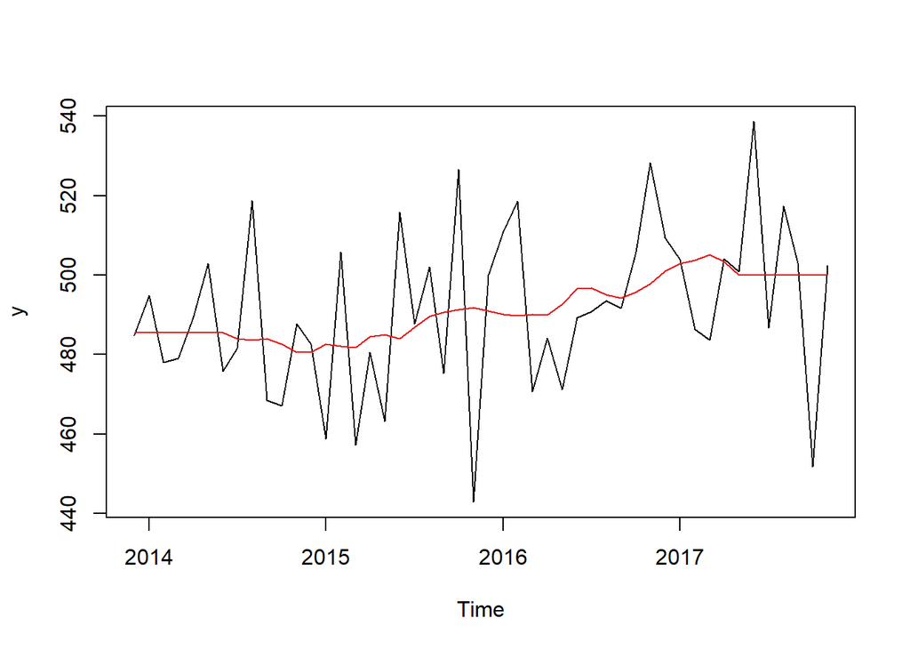

```r
cma <- cmav(y.trn,outplot=1) # The argument outplot produces a plot
```

```r
print(cma)
```

```
##           Jan      Feb      Mar      Apr      May      Jun      Jul      Aug
## 2013
## 2014 485.6067 485.6067 485.6067 485.6067 485.6067 485.6069 484.0131 483.6655
## 2015 482.5819 482.1404 481.7245 484.4825 485.0931 483.9505 486.8426 489.5390
## 2016 490.0501 489.8257 490.1591 489.9801 492.6687 496.6175 496.7203 495.0872
## 2017 502.8887 503.7104 505.1768 503.4005 500.0795 500.0798 500.0798 500.0798
##           Sep      Oct      Nov      Dec
## 2013                            485.6067
## 2014 483.9164 482.6527 480.6365 480.6526
## 2015 490.6202 491.3220 491.8057 491.0319
## 2016 494.2917 495.6636 497.7222 501.0080
## 2017 500.0798 500.0798 500.0798
```

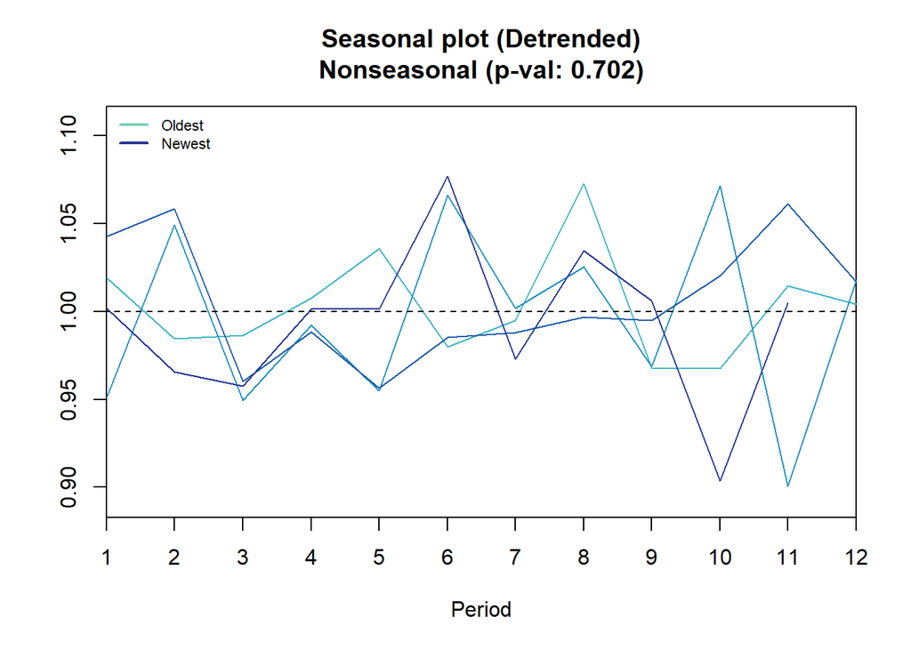

```
## Results of statistical testing
## Evidence of trend: TRUE  (pval: 0)
## Evidence of seasonality: FALSE  (pval: 0.702)
```

```r
seasplot(y.trn)
```

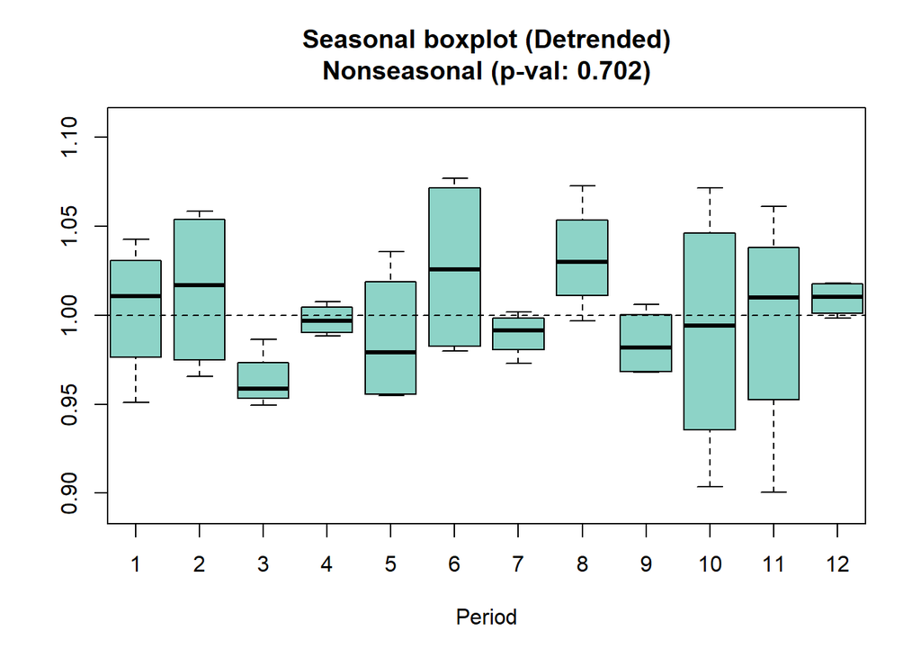

```
## Results of statistical testing
## Evidence of trend: TRUE  (pval: 0)
## Evidence of seasonality: FALSE  (pval: 0.702)
```

```r
seasplot(y.trn,outplot=2)
```

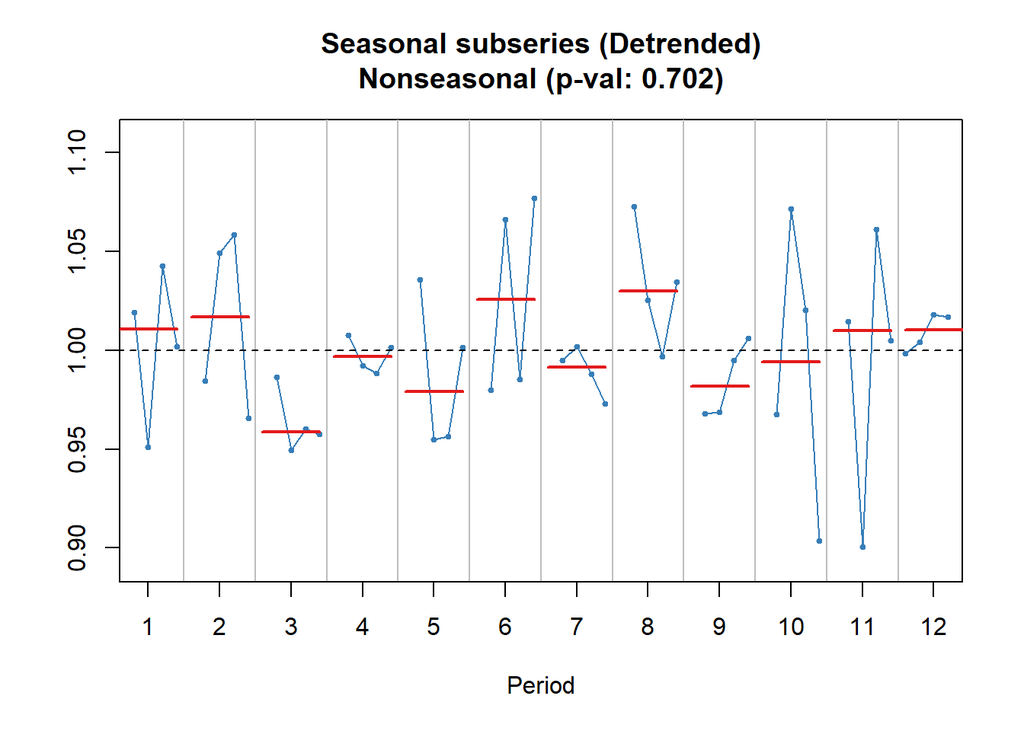

```
## Results of statistical testing
## Evidence of trend: TRUE  (pval: 0)
## Evidence of seasonality: FALSE  (pval: 0.702)
```

```r
seasplot(y.trn,outplot=3)
```

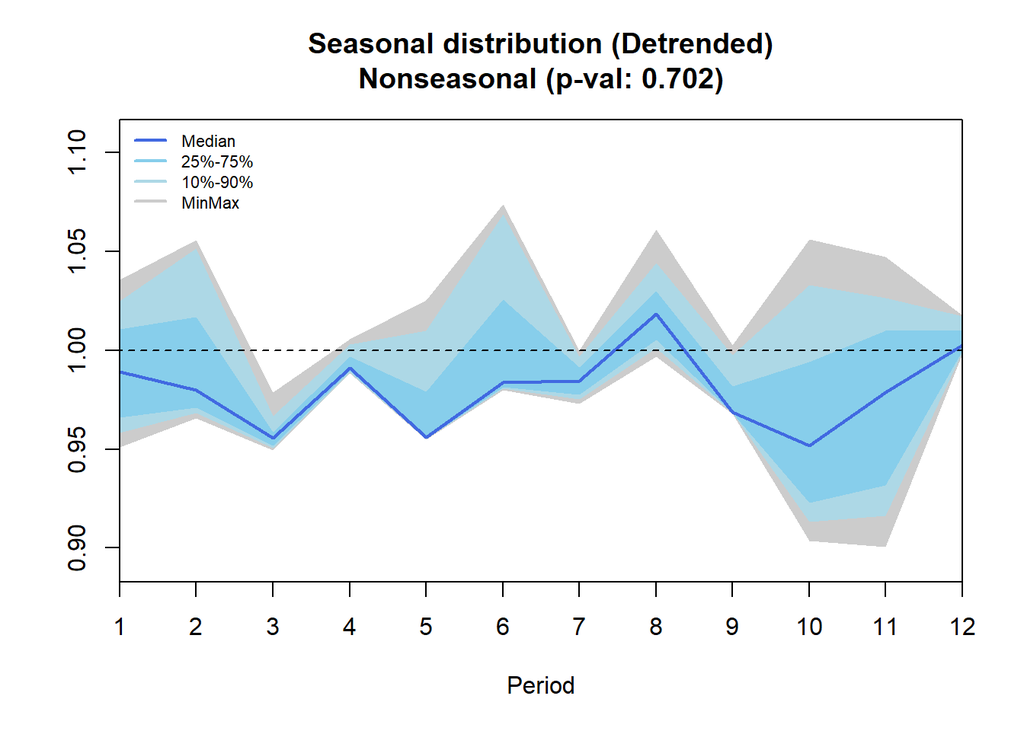

```
## Results of statistical testing
## Evidence of trend: TRUE  (pval: 0)
## Evidence of seasonality: FALSE  (pval: 0.702)
```

```r
seasplot(y.trn,outplot=4)
```

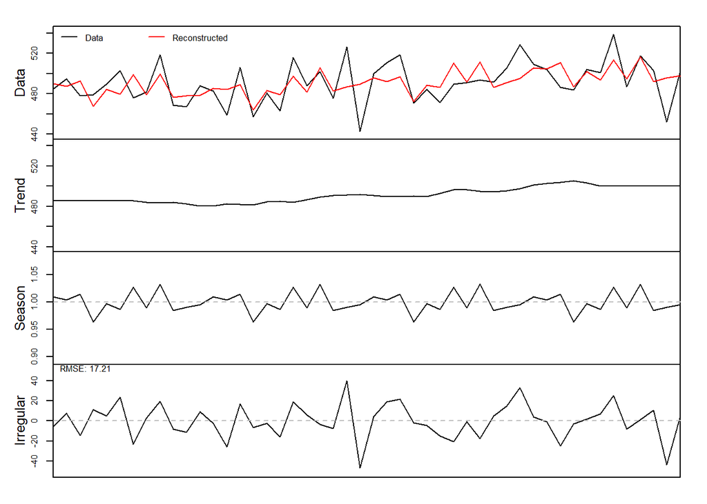

```r
dc <- decomp(y.trn,outplot=1)
```

#### Observation

- **Trend Analysis:** Statistically, there appears to be evidence of a trend within the data. However, it is important to note that the visualization graphs do not unequivocally confirm the presence of this trend, warranting further investigation.
- **Seasonality Assessment:** Conversely, Statistical analysis fails to detect any significant seasonality within the dataset. This finding is corroborated by the visualization graph, which illustrates the absence of repetitive patterns typically indicative of seasonality.
- **Conclusion:** In summary, while there is some statistical indication of a trend, it is not definitively supported by the visualization graphs. Additionally, there is a clear absence of seasonality within this time series data.

### LevelShift - Time Series

#### Load Data

```r
y <- Y[,3]
print(y)
```

```
##  [1] 687.9850 687.2746 682.8712 718.7764 733.6778 662.9156 702.4218 730.0287
##  [9] 738.7401 749.2881 736.9927 718.5036 705.9423 745.0246 733.2173 739.2857
## [17] 746.1170 719.2866 718.5111 766.2992 699.9061 743.0381 755.6695 770.0157
## [25] 777.8046 758.6962 754.8626 734.4742 698.7198 729.9694 817.1418 871.6709
## [33] 864.1622 879.3891 839.3719 861.2266 879.8566 882.4076 843.9639 859.9885
## [41] 850.4899 839.6968 864.6994 837.5950 865.0451 897.2701 826.6039 890.3355
## [49] 855.6515 875.2794 875.9614 888.6250 815.7227 901.7243 852.6084 875.0078
## [57] 877.0743 838.1259 840.1391 869.4072
```

```r
y <- ts(y,frequency=12,end=c(2018,11))
# The syntax of end is c(Year,Month), or more generally
# c(season,seasonal period).
print(y)
```

```
##           Jan      Feb      Mar      Apr      May      Jun      Jul      Aug
## 2013
## 2014 687.2746 682.8712 718.7764 733.6778 662.9156 702.4218 730.0287 738.7401
## 2015 745.0246 733.2173 739.2857 746.1170 719.2866 718.5111 766.2992 699.9061
## 2016 758.6962 754.8626 734.4742 698.7198 729.9694 817.1418 871.6709 864.1622
## 2017 882.4076 843.9639 859.9885 850.4899 839.6968 864.6994 837.5950 865.0451
## 2018 875.2794 875.9614 888.6250 815.7227 901.7243 852.6084 875.0078 877.0743
##           Sep      Oct      Nov      Dec
## 2013                            687.9850
## 2014 749.2881 736.9927 718.5036 705.9423
## 2015 743.0381 755.6695 770.0157 777.8046
## 2016 879.3891 839.3719 861.2266 879.8566
## 2017 897.2701 826.6039 890.3355 855.6515
## 2018 838.1259 840.1391 869.4072
```

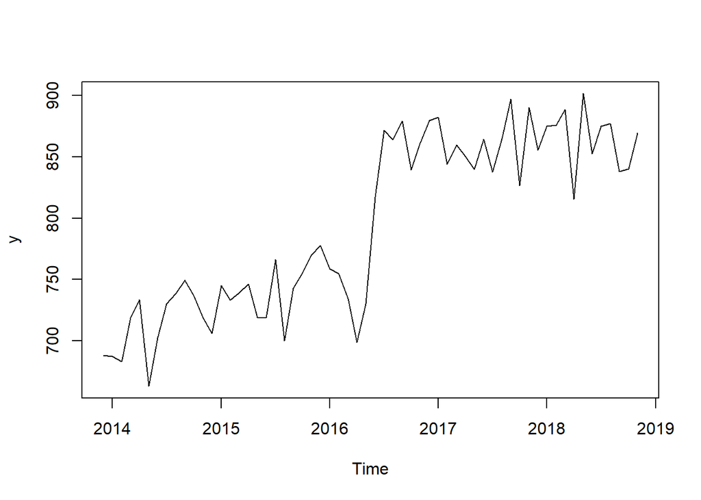

```r
plot(y)
```

#### Constructing estimation and hold-out sets

```r
y.tst <- tail(y,12)
y.trn <- head(y,48)
```

#### Exploration

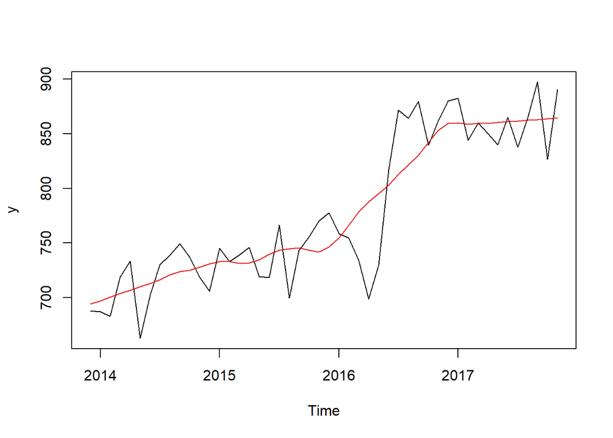

```r
cma <- cmav(y.trn,outplot=1)
```

```r
print(cma)
```

```
##           Jan      Feb      Mar      Apr      May      Jun      Jul      Aug
## 2013
## 2014 697.4083 700.5675 703.7267 706.8859 710.0452 713.2045 716.3590 720.8630
## 2015 733.2561 733.1493 731.2708 731.7885 734.7131 739.8537 743.4176 744.8891
## 2016 754.9402 766.1747 778.7000 787.8689 795.1570 803.2096 812.6164 821.4836
## 2017 859.9904 858.6074 859.3892 859.6023 860.2832 860.9623 861.6416 862.3208
##           Sep      Oct      Nov      Dec
## 2013                            694.2490
## 2014 723.8153 725.1882 728.0552 731.0744
## 2015 745.5905 743.4152 741.8854 746.4401
## 2016 830.4259 841.9794 852.8752 859.4287
## 2017 863.0000 863.6792 864.3585
```

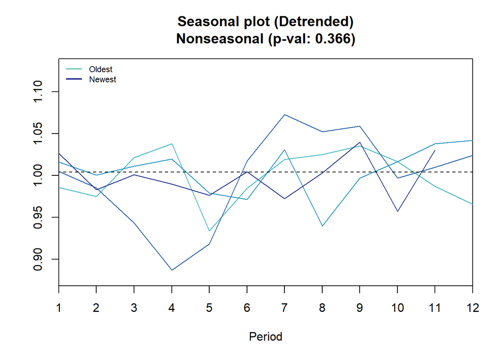

```
## Results of statistical testing
## Evidence of trend: TRUE  (pval: 0)
## Evidence of seasonality: FALSE  (pval: 0.366)
```

```r
seasplot(y.trn)
```

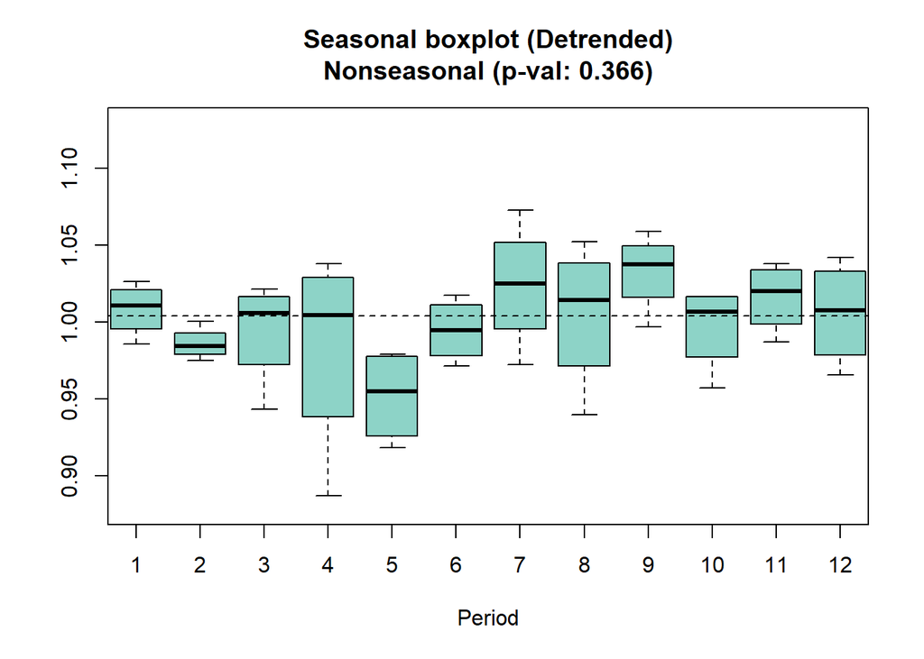

```
## Results of statistical testing
## Evidence of trend: TRUE  (pval: 0)
## Evidence of seasonality: FALSE  (pval: 0.366)
```

```r
seasplot(y.trn,outplot=2)
```

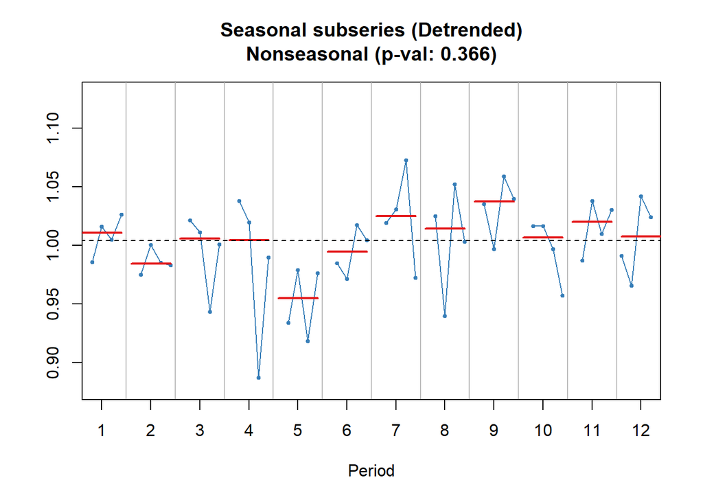

```
## Results of statistical testing
## Evidence of trend: TRUE  (pval: 0)
## Evidence of seasonality: FALSE  (pval: 0.366)
```

```r
seasplot(y.trn,outplot=3)
```

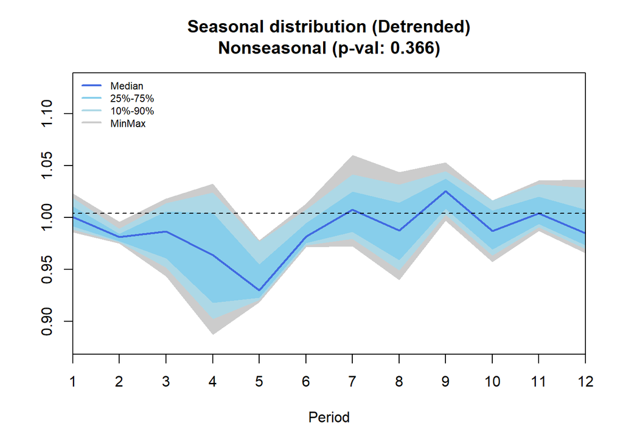

```
## Results of statistical testing
## Evidence of trend: TRUE  (pval: 0)
## Evidence of seasonality: FALSE  (pval: 0.366)
```

```r
seasplot(y.trn,outplot=4)
```

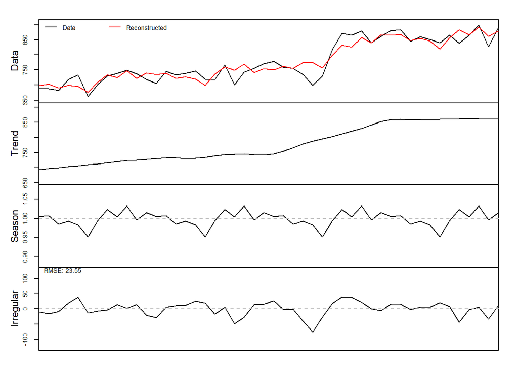

```r
dc <- decomp(y.trn,outplot=1)
```

#### Observation

**Trend Analysis:** Statistical assessment unequivocally identifies the presence of a discernible trend within the dataset. This finding is further validated by the visualization graph, which unmistakably portrays the existence of a trend.

**Seasonality Evaluation:** In stark contrast, rigorous statistical analysis fails to detect any significant seasonality within the dataset. This outcome is in alignment with the visualization graph, which provides compelling evidence of the absence of repetitive patterns indicative of seasonality.

**Conclusion:** In summary, analysis conclusively asserts the existence of a trend while simultaneously discounting the presence of seasonality within this time series data.

### Trend_A - Time Series

#### Load Data

```r
y <- Y[,4]
print(y)
```

```
##  [1] 4811.254 4785.975 4746.325 4791.332 4748.645 4733.944 4860.476 4837.283
##  [9] 4805.012 4792.921 4772.660 4719.646 4774.294 4725.823 4674.412 4758.510
## [17] 4800.288 4734.328 4626.869 4611.724 4660.885 4696.642 4606.577 4644.255
## [25] 4704.586 4574.058 4602.505 4638.239 4440.421 4525.592 4506.761 4500.839
## [33] 4407.498 4415.625 4392.075 4330.295 4331.313 4244.963 4245.427 4117.801
## [41] 4282.850 4338.188 4261.027 4274.002 4142.335 4115.690 4146.546 4059.242
## [49] 4110.735 4026.853 4005.306 3959.988 3941.407 3809.953 3833.826 3724.205
## [57] 3664.212 3630.718 3727.921 3539.250
```

```r
y <- ts(y,frequency=12,end=c(2018,11))
print(y)
```

```
##           Jan      Feb      Mar      Apr      May      Jun      Jul      Aug
## 2013
## 2014 4785.975 4746.325 4791.332 4748.645 4733.944 4860.476 4837.283 4805.012
## 2015 4725.823 4674.412 4758.510 4800.288 4734.328 4626.869 4611.724 4660.885
## 2016 4574.058 4602.505 4638.239 4440.421 4525.592 4506.761 4500.839 4407.498
## 2017 4244.963 4245.427 4117.801 4282.850 4338.188 4261.027 4274.002 4142.335
## 2018 4026.853 4005.306 3959.988 3941.407 3809.953 3833.826 3724.205 3664.212
##           Sep      Oct      Nov      Dec
## 2013                            4811.254
## 2014 4792.921 4772.660 4719.646 4774.294
## 2015 4696.642 4606.577 4644.255 4704.586
## 2016 4415.625 4392.075 4330.295 4331.313
## 2017 4115.690 4146.546 4059.242 4110.735
## 2018 3630.718 3727.921 3539.250
```

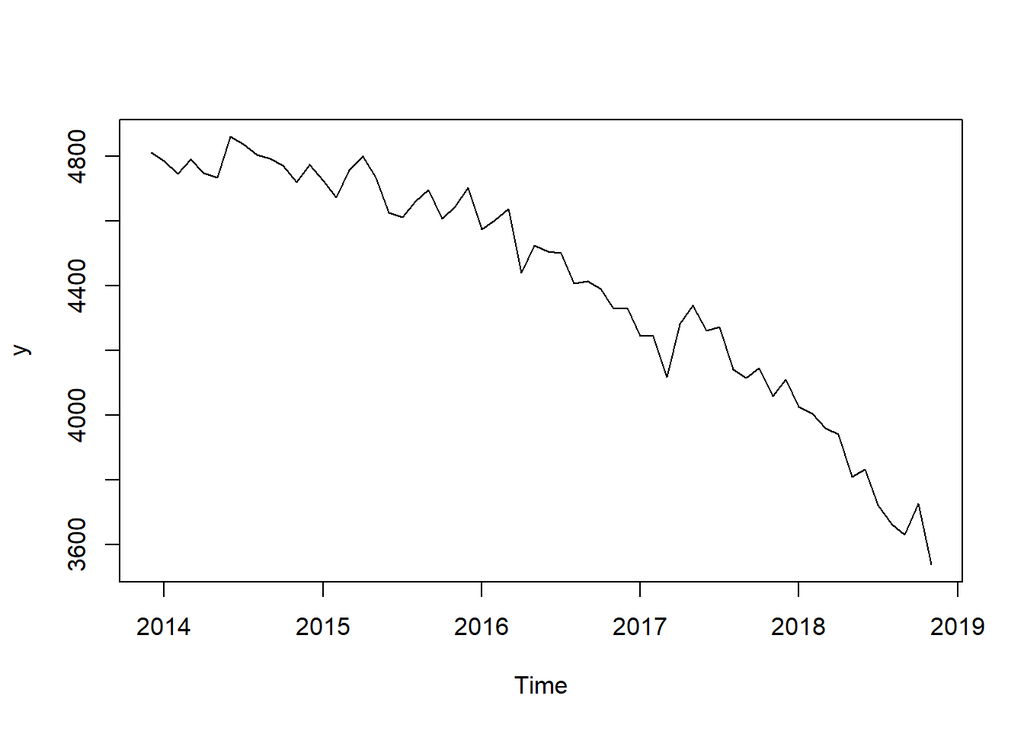

```r
plot(y)
```

#### Constructing estimation and hold-out sets

```r
y.tst <- tail(y,12)
y.trn <- head(y,48)
```

#### Exploration

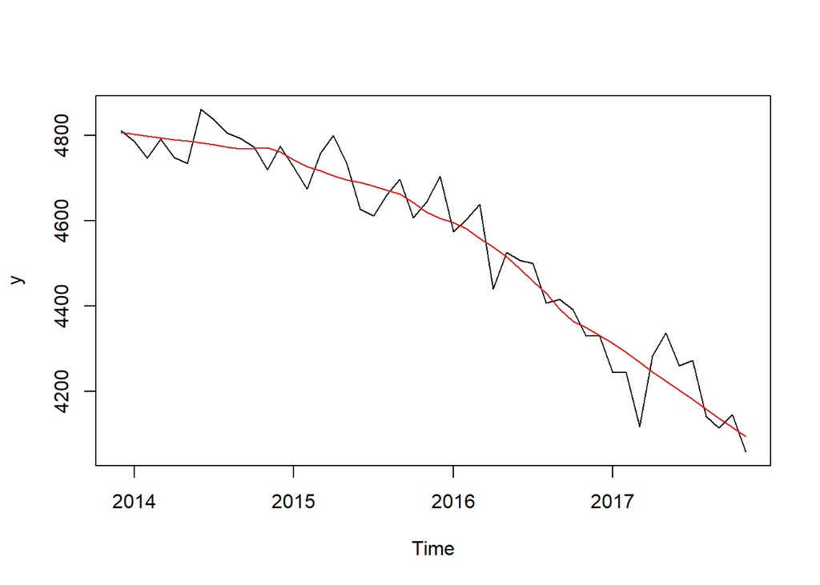

```r
cma <- cmav(y.trn,outplot=1)
```

```r
print(cma)
```

```
##           Jan      Feb      Mar      Apr      May      Jun      Jul      Aug
## 2013
## 2014 4802.483 4798.436 4794.389 4790.343 4786.296 4782.249 4778.203 4772.700
## 2015 4742.439 4727.035 4717.019 4706.087 4696.025 4689.979 4680.751 4671.432
## 2016 4596.400 4581.222 4558.955 4538.309 4516.289 4487.655 4458.389 4429.799
## 2017 4312.873 4292.374 4268.828 4246.100 4224.576 4203.051 4181.527 4160.003
##           Sep      Oct      Nov      Dec
## 2013                            4806.529
## 2014 4768.337 4769.121 4771.289 4761.571
## 2015 4663.424 4643.418 4619.727 4606.025
## 2016 4393.236 4364.985 4350.611 4332.564
## 2017 4138.479 4116.954 4095.430
```

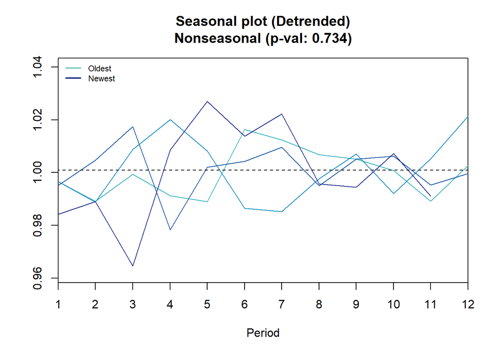

```
## Results of statistical testing
## Evidence of trend: TRUE  (pval: 0)
## Evidence of seasonality: FALSE  (pval: 0.734)
```

```r
seasplot(y.trn)
```

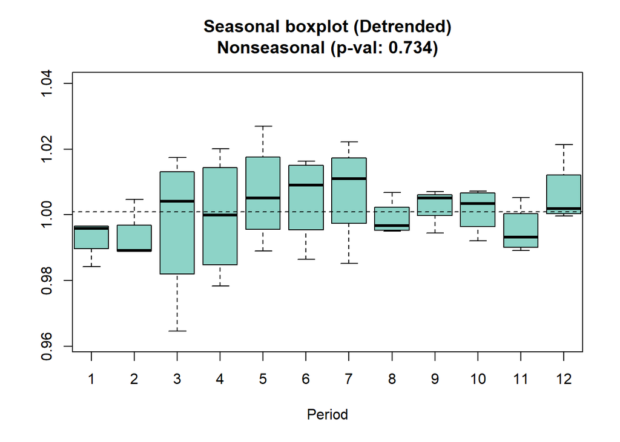

```
## Results of statistical testing
## Evidence of trend: TRUE  (pval: 0)
## Evidence of seasonality: FALSE  (pval: 0.734)
```

```r
seasplot(y.trn,outplot=2)
```

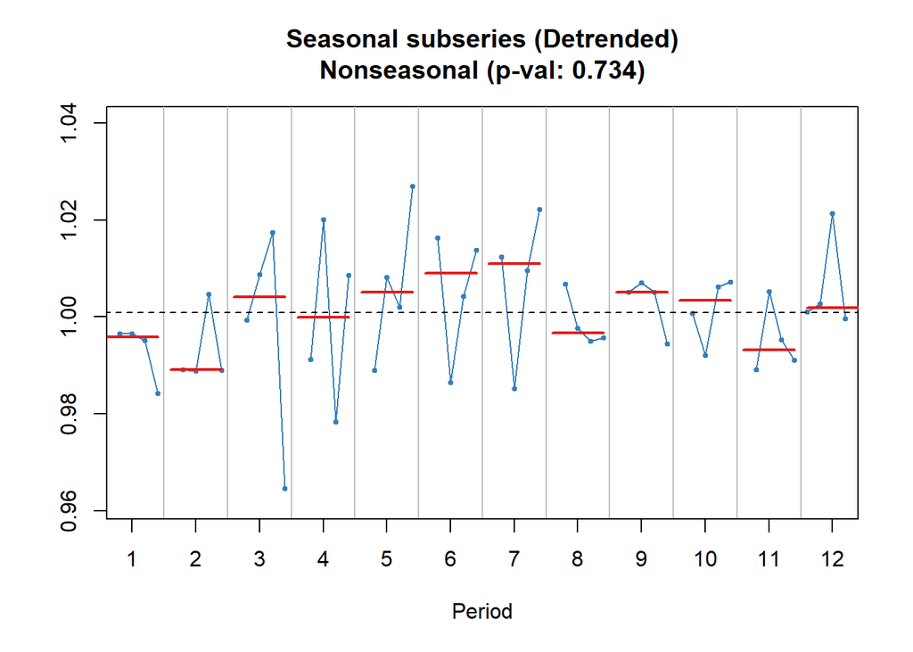

```
## Results of statistical testing
## Evidence of trend: TRUE  (pval: 0)
## Evidence of seasonality: FALSE  (pval: 0.734)
```

```r
seasplot(y.trn,outplot=3)
```

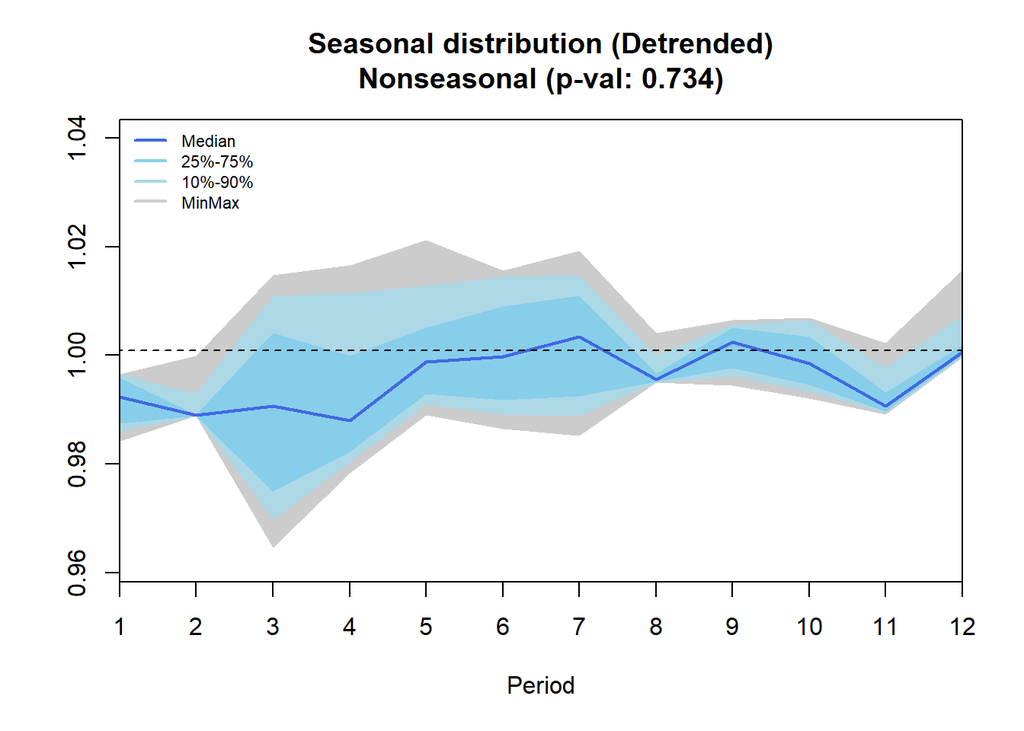

```
## Results of statistical testing
## Evidence of trend: TRUE  (pval: 0)
## Evidence of seasonality: FALSE  (pval: 0.734)
```

```r
seasplot(y.trn,outplot=4)
```

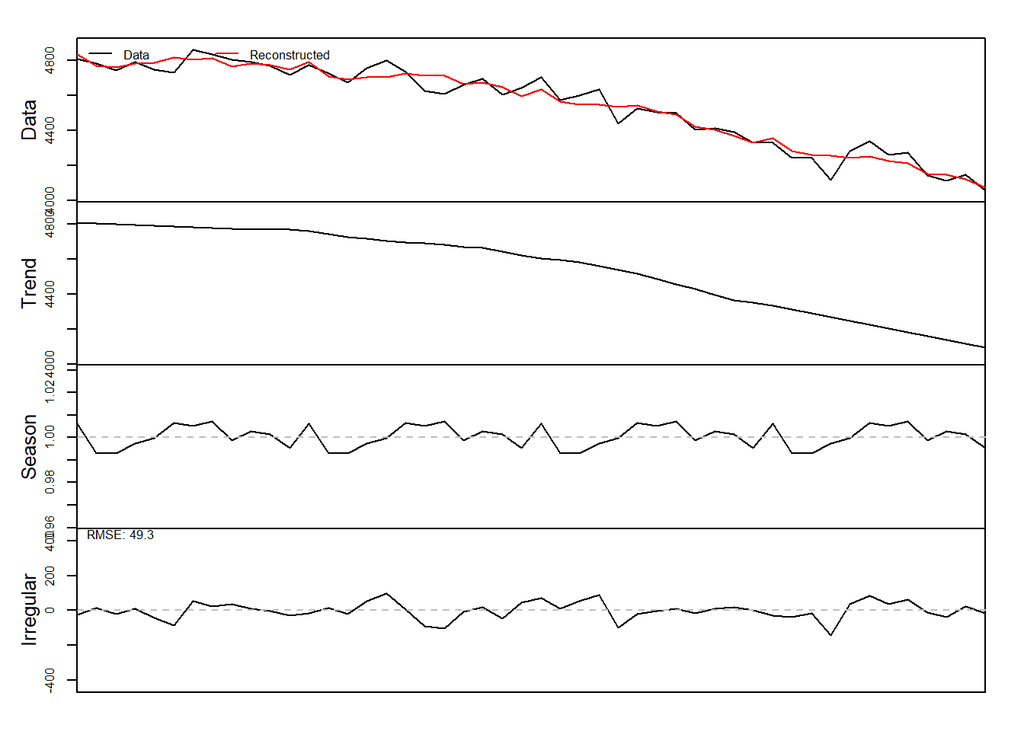

```r
dc <- decomp(y.trn,outplot=1)
```

#### Observation

- **Trend Analysis:** The statistical analysis conducted indicates the presence of a discernible trend within the dataset, a conclusion further supported by the visualization graphs.
- **Seasonality Assessment:** Conversely, the statistical examination unequivocally affirms the absence of significant seasonality within the dataset. This observation aligns with the visualization graphs, which lack repetitive patterns indicative of seasonality.
- **Conclusion:** In summary, the analysis confirms the existence of a trend while conclusively ruling out the presence of seasonality within this time series data.

### Trend_B - Time Series

#### Load Data

```r
y <- Y[,5]
print(y)
```

```
##  [1] 1911.870 1950.702 2074.533 2027.001 2168.685 2134.204 2143.586 2203.608
##  [9] 2269.670 2288.267 2318.459 2354.575 2348.642 2410.823 2425.872 2443.260
## [17] 2418.268 2441.637 2501.871 2490.253 2547.162 2597.297 2579.102 2632.576
## [25] 2651.229 2654.030 2664.998 2659.445 2752.220 2759.949 2689.676 2819.194
## [33] 2811.123 2817.265 2903.696 2847.171 2960.159 2914.750 2927.487 2980.284
## [41] 2940.516 2956.346 2963.466 2938.626 3045.697 3047.369 3106.114 3071.805
## [49] 3021.431 3070.378 3129.974 3118.365 3168.412 3153.210 3128.485 3174.239
## [57] 3215.049 3149.663 3250.898 3212.137
```

```r
y <- ts(y,frequency=12,end=c(2018,11))
print(y)
```

```
##           Jan      Feb      Mar      Apr      May      Jun      Jul      Aug
## 2013
## 2014 1950.702 2074.533 2027.001 2168.685 2134.204 2143.586 2203.608 2269.670
## 2015 2410.823 2425.872 2443.260 2418.268 2441.637 2501.871 2490.253 2547.162
## 2016 2654.030 2664.998 2659.445 2752.220 2759.949 2689.676 2819.194 2811.123
## 2017 2914.750 2927.487 2980.284 2940.516 2956.346 2963.466 2938.626 3045.697
## 2018 3070.378 3129.974 3118.365 3168.412 3153.210 3128.485 3174.239 3215.049
##           Sep      Oct      Nov      Dec
## 2013                            1911.870
## 2014 2288.267 2318.459 2354.575 2348.642
## 2015 2597.297 2579.102 2632.576 2651.229
## 2016 2817.265 2903.696 2847.171 2960.159
## 2017 3047.369 3106.114 3071.805 3021.431
## 2018 3149.663 3250.898 3212.137
```

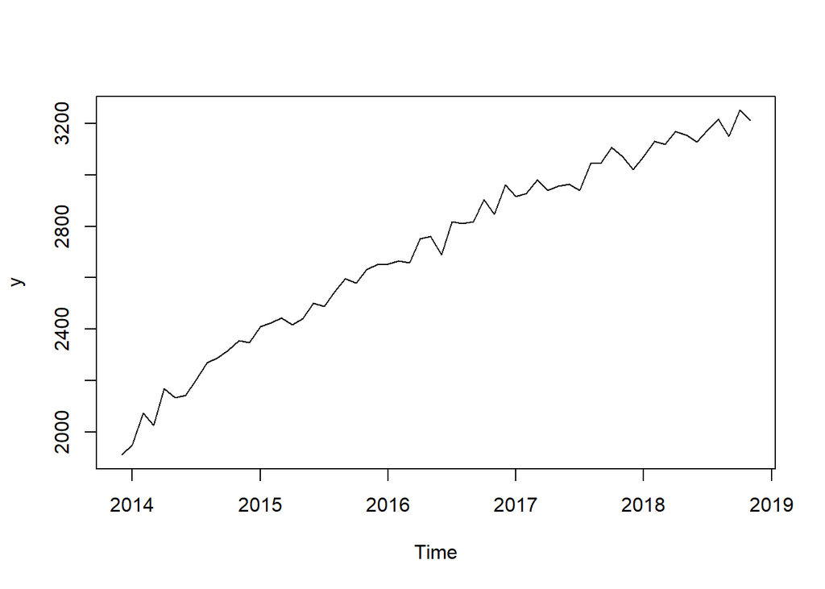

```r
plot(y)
```

#### Constructing estimation and hold-out sets

```r
y.tst <- tail(y,12)
y.trn <- head(y,48)
```

#### Exploration

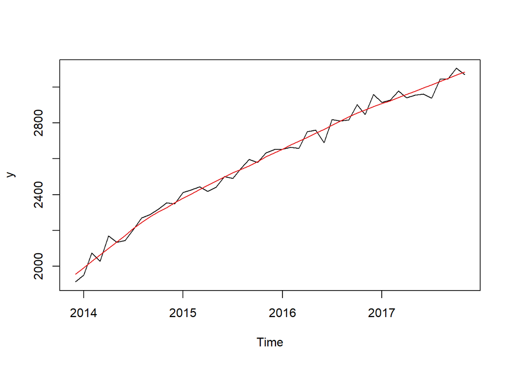

```r
cma <- cmav(y.trn,outplot=1)
```

```r
print(cma)
```

```
##           Jan      Feb      Mar      Apr      May      Jun      Jul      Aug
## 2013
## 2014 1991.246 2027.389 2063.532 2099.676 2135.819 2171.962 2209.333 2243.144
## 2015 2380.690 2404.195 2428.634 2452.370 2474.813 2499.005 2521.746 2541.843
## 2016 2653.534 2678.238 2698.402 2721.092 2743.558 2765.372 2789.107 2810.907
## 2017 2908.431 2923.181 2942.543 2960.565 2978.358 2996.234 3014.110 3031.985
##           Sep      Oct      Nov      Dec
## 2013                            1955.102
## 2014 2275.127 2302.870 2326.079 2353.817
## 2015 2560.815 2583.737 2610.915 2632.003
## 2016 2835.213 2856.427 2872.456 2892.047
## 2017 3049.861 3067.736 3085.612
```

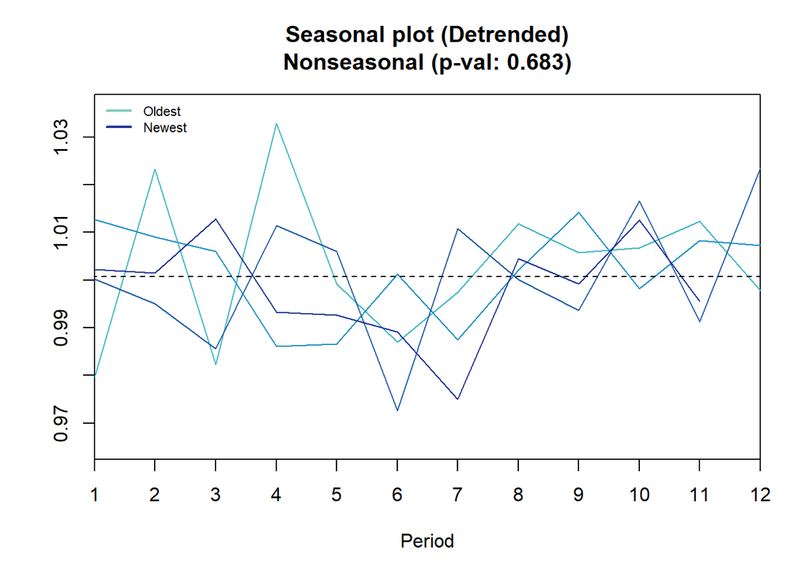

```
## Results of statistical testing
## Evidence of trend: TRUE  (pval: 0)
## Evidence of seasonality: FALSE  (pval: 0.683)
```

```r
seasplot(y.trn)
```

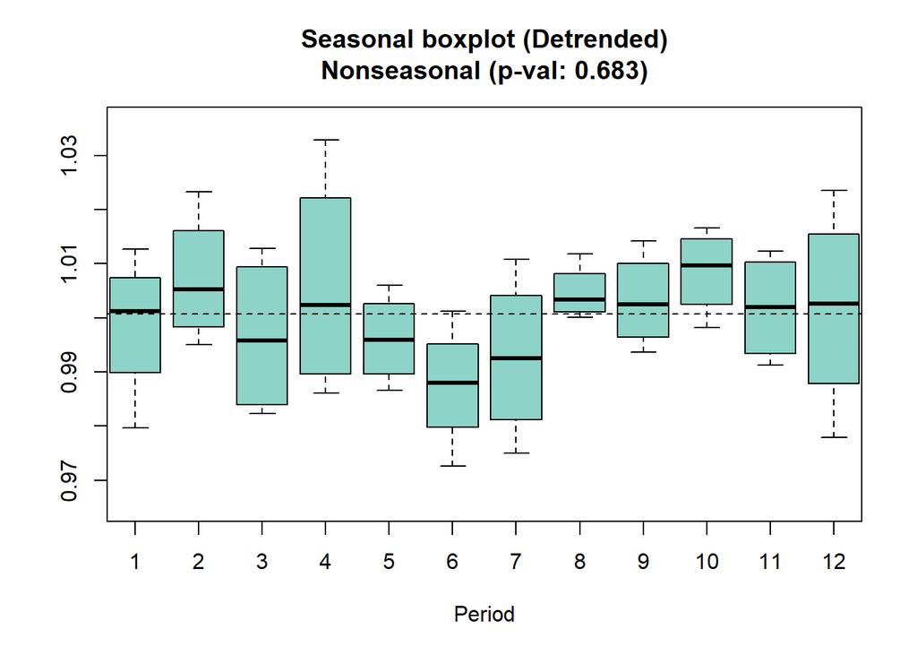

```
## Results of statistical testing
## Evidence of trend: TRUE  (pval: 0)
## Evidence of seasonality: FALSE  (pval: 0.683)
```

```r
seasplot(y.trn,outplot=2)
```

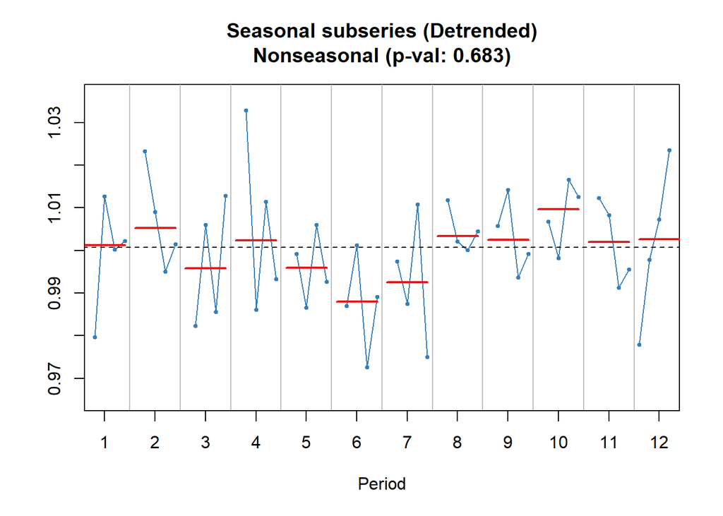

```
## Results of statistical testing
## Evidence of trend: TRUE  (pval: 0)
## Evidence of seasonality: FALSE  (pval: 0.683)
```

```r
seasplot(y.trn,outplot=3)
```

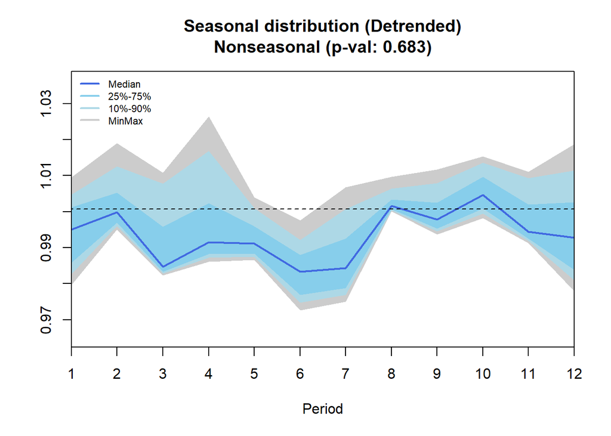

```
## Results of statistical testing
## Evidence of trend: TRUE  (pval: 0)
## Evidence of seasonality: FALSE  (pval: 0.683)
```

```r
seasplot(y.trn,outplot=4)
```

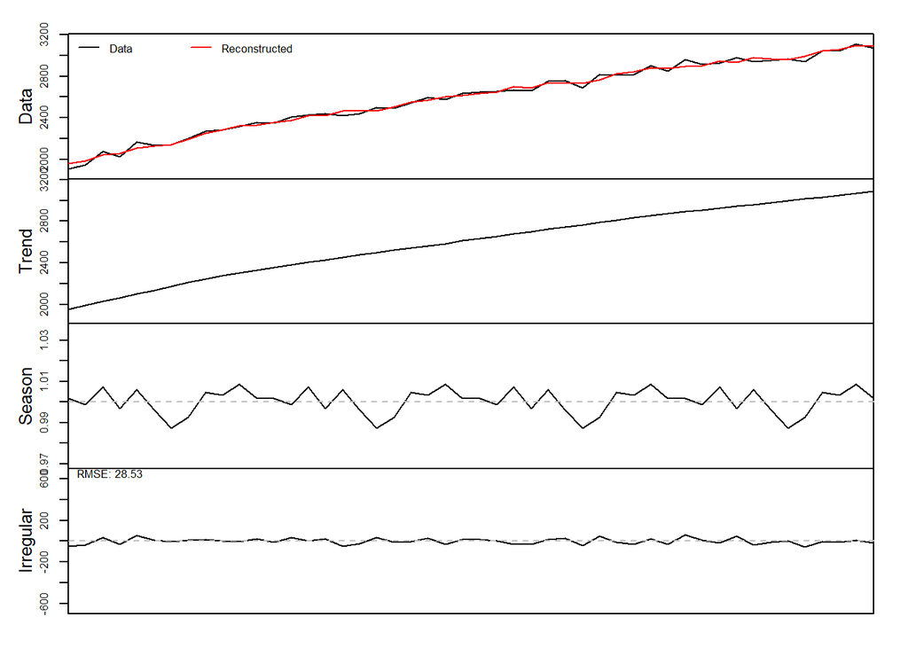

```r
dc <- decomp(y.trn,outplot=1)
```

#### Observation

- **Trend Analysis:** Through a meticulous examination of the data, it is evident that a discernible trend exists, a conclusion supported by the visualization graphs.
- **Seasonality Assessment:** Conversely, the analysis conducted demonstrates the absence of significant seasonality within the dataset. This determination aligns with the visual evidence presented in the graphs, which notably lack any recurring patterns indicative of seasonality.
- **Conclusion:** In summary, the analysis affirms the presence of a trend while simultaneously discounting the presence of seasonality within this time series data.

### Season_A - Time Series

#### Load Data

```r
y <- Y[,6]
print(y)
```

```
##  [1]  231.1930  467.6818  649.9551  465.7579  726.8946  926.6489 1043.4760
##  [8]  890.6451  936.9840  972.0107  392.7123  773.3365  231.3019  482.3914
## [15]  686.6944  508.5456  783.0867  948.8349 1033.9909  885.7968  884.2049
## [22]  950.9984  414.5146  831.5753  249.5404  490.2678  702.6915  487.3626
## [29]  751.0515  933.2986 1047.3553  933.6356  917.5312  978.5181  375.8654
## [36]  743.5117  230.7031  507.5720  737.4308  534.9390  896.3776 1060.8528
## [43] 1164.6262 1044.2644 1051.6022 1154.3498  468.5850  876.5367  263.3852
## [50]  515.9486  734.3243  484.5399  765.2680  920.0402 1037.8768  911.4822
## [57]  948.8460 1026.4180  385.7735  795.1730
```

```r
y <- ts(y,frequency=12,end=c(2018,11))
print(y)
```

```
##            Jan       Feb       Mar       Apr       May       Jun       Jul
## 2013
## 2014  467.6818  649.9551  465.7579  726.8946  926.6489 1043.4760  890.6451
## 2015  482.3914  686.6944  508.5456  783.0867  948.8349 1033.9909  885.7968
## 2016  490.2678  702.6915  487.3626  751.0515  933.2986 1047.3553  933.6356
## 2017  507.5720  737.4308  534.9390  896.3776 1060.8528 1164.6262 1044.2644
## 2018  515.9486  734.3243  484.5399  765.2680  920.0402 1037.8768  911.4822
##            Aug       Sep       Oct       Nov       Dec
## 2013                                          231.1930
## 2014  936.9840  972.0107  392.7123  773.3365  231.3019
## 2015  884.2049  950.9984  414.5146  831.5753  249.5404
## 2016  917.5312  978.5181  375.8654  743.5117  230.7031
## 2017 1051.6022 1154.3498  468.5850  876.5367  263.3852
## 2018  948.8460 1026.4180  385.7735  795.1730
```

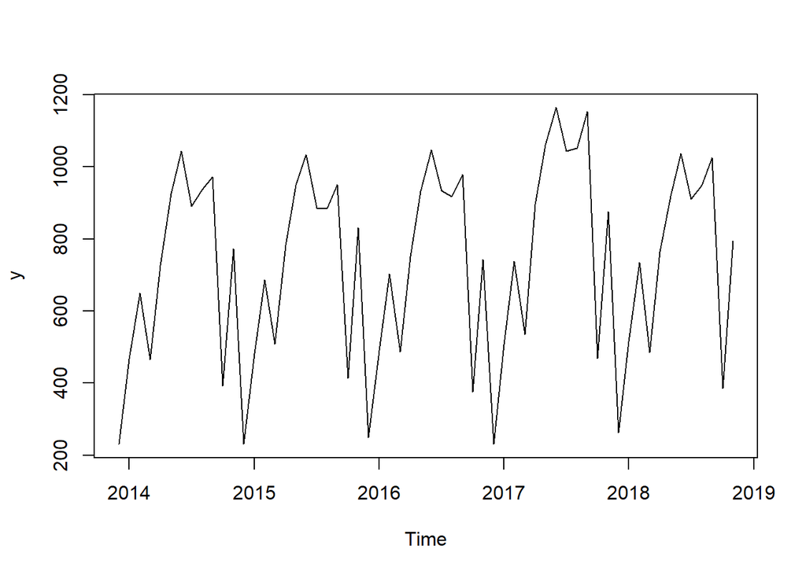

```r
plot(y)
```

#### Constructing estimation and hold-out sets

```r
y.tst <- tail(y,12)
y.trn <- head(y,48)
```

#### Exploration

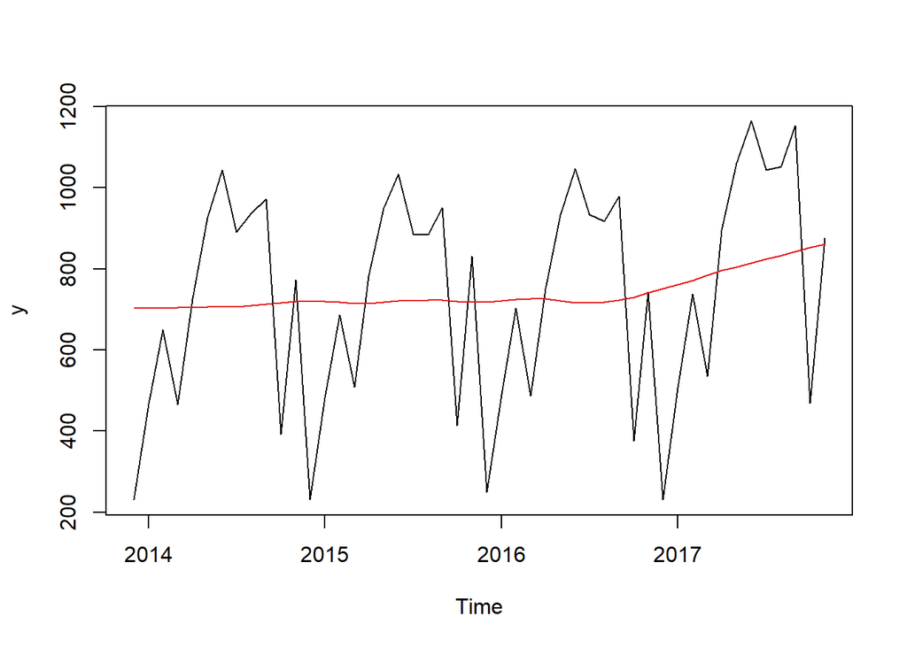

```r
cma <- cmav(y.trn,outplot=1)
```

```r
print(cma)
```

```
##           Jan      Feb      Mar      Apr      May      Jun      Jul      Aug
## 2013
## 2014 703.3583 703.9758 704.5933 705.2107 705.8282 706.4458 707.0633 709.2070
## 2015 719.8425 717.4414 714.3667 714.3997 717.7347 720.9213 722.0094 723.0041
## 2016 721.0481 724.4300 726.9652 726.5015 721.2218 716.7676 716.7037 718.8722
## 2017 761.4065 771.6023 784.5149 795.7046 805.1106 814.5168 823.9228 833.3288
##           Sep      Oct      Nov      Dec
## 2013                            702.7408
## 2014 712.5206 716.6448 719.9105 720.4397
## 2015 722.7880 720.5706 718.5885 718.4980
## 2016 722.3020 730.3396 741.7096 751.9107
## 2017 842.7349 852.1409 861.5469
```

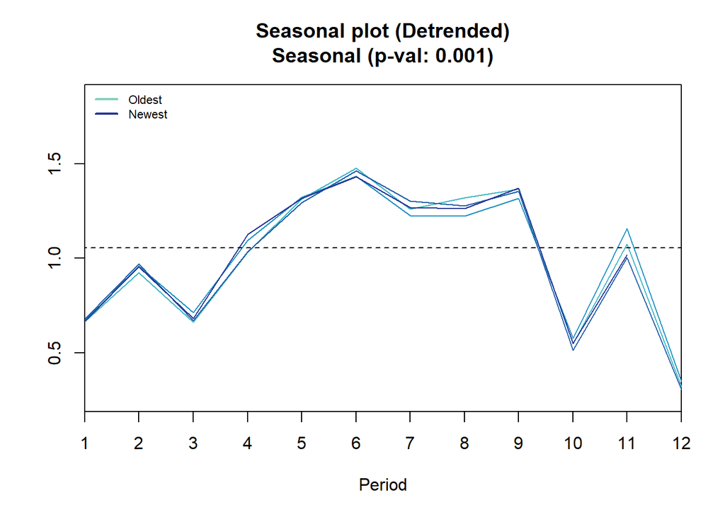

```
## Results of statistical testing
## Evidence of trend: TRUE  (pval: 0)
## Evidence of seasonality: TRUE  (pval: 0.001)
```

```r
seasplot(y.trn)
```

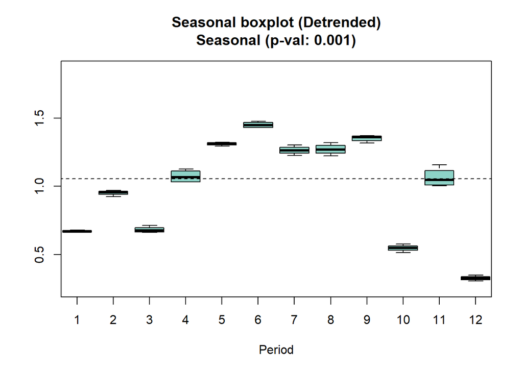

```
## Results of statistical testing
## Evidence of trend: TRUE  (pval: 0)
## Evidence of seasonality: TRUE  (pval: 0.001)
```

```r
seasplot(y.trn,outplot=2)
```

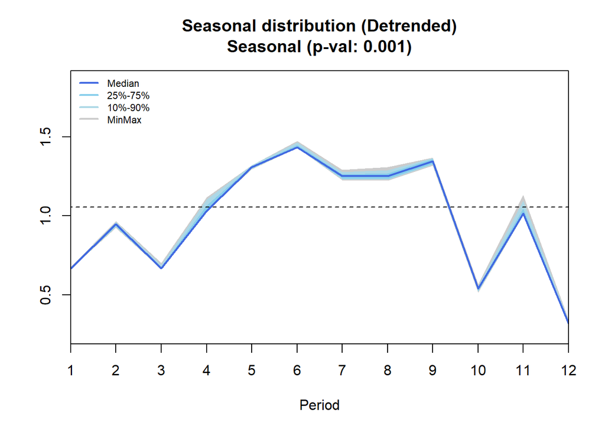

```
## Results of statistical testing
## Evidence of trend: TRUE  (pval: 0)
## Evidence of seasonality: TRUE  (pval: 0.001)
```

```r
seasplot(y.trn,outplot=4)
```

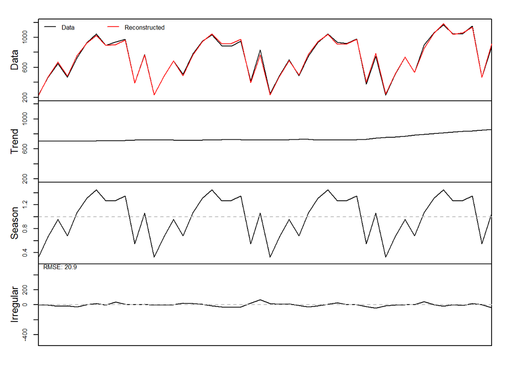

```r
dc <- decomp(y.trn,outplot=1)
```

### Season_B - Time Series

#### Load Data

```r
y <- Y[,7]
print(y)
```

```
##  [1] 229.3392 308.8277 271.2460 293.9912 491.7330 754.2631 732.8038 482.7710
##  [9] 548.9135 676.5493 349.2937 260.8061 194.3558 268.9270 242.6627 243.3807
## [17] 416.5342 637.2254 643.0106 449.8246 505.8062 645.9131 339.8396 227.8289
## [25] 219.6523 330.9740 273.7864 262.4567 437.6518 666.4505 638.4910 470.9215
## [33] 565.4009 676.0848 360.7307 282.9457 178.8305 260.3417 277.9441 288.4126
## [41] 535.3208 818.7349 771.2875 584.1875 625.2942 795.1606 397.7713 318.8312
## [49] 231.9475 317.1494 328.6238 300.6523 525.8733 807.4535 743.6858 557.7259
## [57] 626.3542 809.1212 386.1633 303.0199
```

```r
y <- ts(y,frequency=12,end=c(2018,11))
print(y)
```

```
##           Jan      Feb      Mar      Apr      May      Jun      Jul      Aug
## 2013
## 2014 308.8277 271.2460 293.9912 491.7330 754.2631 732.8038 482.7710 548.9135
## 2015 268.9270 242.6627 243.3807 416.5342 637.2254 643.0106 449.8246 505.8062
## 2016 330.9740 273.7864 262.4567 437.6518 666.4505 638.4910 470.9215 565.4009
## 2017 260.3417 277.9441 288.4126 535.3208 818.7349 771.2875 584.1875 625.2942
## 2018 317.1494 328.6238 300.6523 525.8733 807.4535 743.6858 557.7259 626.3542
##           Sep      Oct      Nov      Dec
## 2013                            229.3392
## 2014 676.5493 349.2937 260.8061 194.3558
## 2015 645.9131 339.8396 227.8289 219.6523
## 2016 676.0848 360.7307 282.9457 178.8305
## 2017 795.1606 397.7713 318.8312 231.9475
## 2018 809.1212 386.1633 303.0199
```

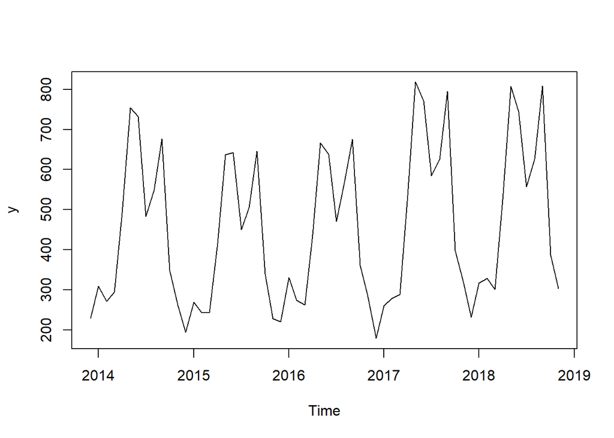

```r
plot(y)
```

#### Constructing estimation and hold-out sets

```r
y.tst <- tail(y,12)
y.trn <- head(y,48)
```

#### Exploration

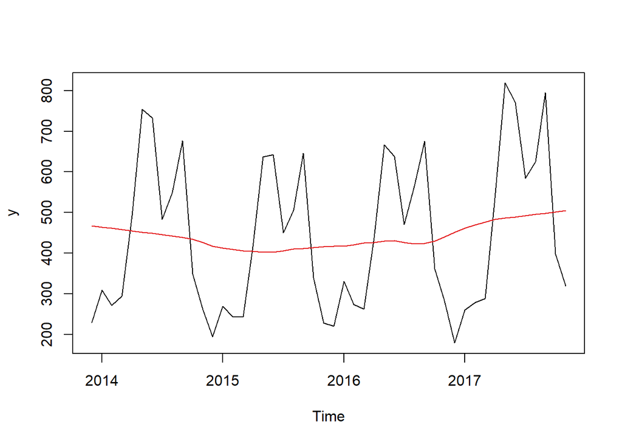

```r
cma <- cmav(y.trn,outplot=1)
```

```r
print(cma)
```

```
##           Jan      Feb      Mar      Apr      May      Jun      Jul      Aug
## 2013
## 2014 464.1866 461.0667 457.9468 454.8269 451.7070 448.5872 445.4670 442.6135
## 2015 412.3297 409.1608 406.0882 404.4178 402.6498 402.3298 405.9691 409.8512
## 2016 417.4353 420.7975 424.5377 426.6653 429.8323 430.4280 425.7840 423.0143
## 2017 461.9657 469.1807 476.6378 483.1426 486.1812 489.2230 492.2644 495.3058
##           Sep      Oct      Nov      Dec
## 2013                            467.3065
## 2014 439.3138 434.0717 426.0618 417.4439
## 2015 411.9428 413.6176 415.7152 416.7446
## 2016 424.2690 429.4200 439.8348 451.7131
## 2017 498.3472 501.3887 504.4301
```

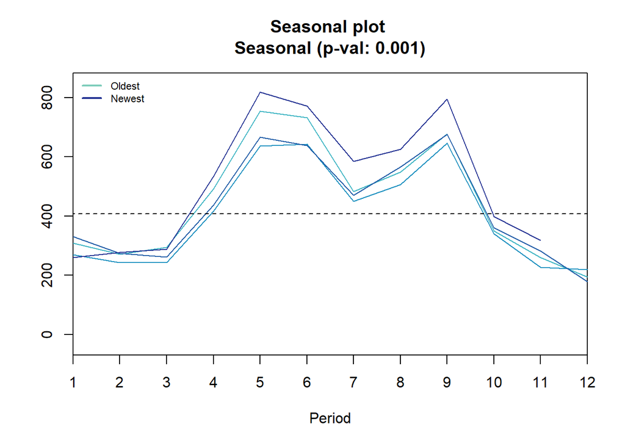

```
## Results of statistical testing
## Evidence of trend: FALSE  (pval: 0.419)
## Evidence of seasonality: TRUE  (pval: 0.001)
```

```r
seasplot(y.trn)
```

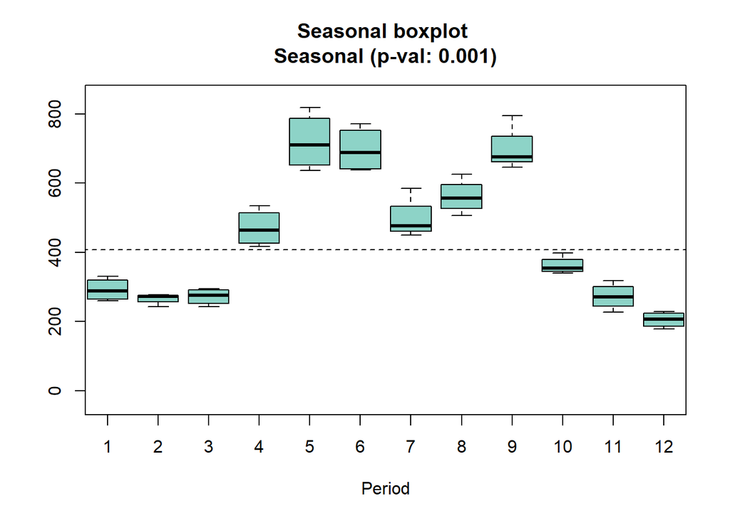

```
## Results of statistical testing
## Evidence of trend: FALSE  (pval: 0.419)
## Evidence of seasonality: TRUE  (pval: 0.001)
```

```r
seasplot(y.trn,outplot=2)
```

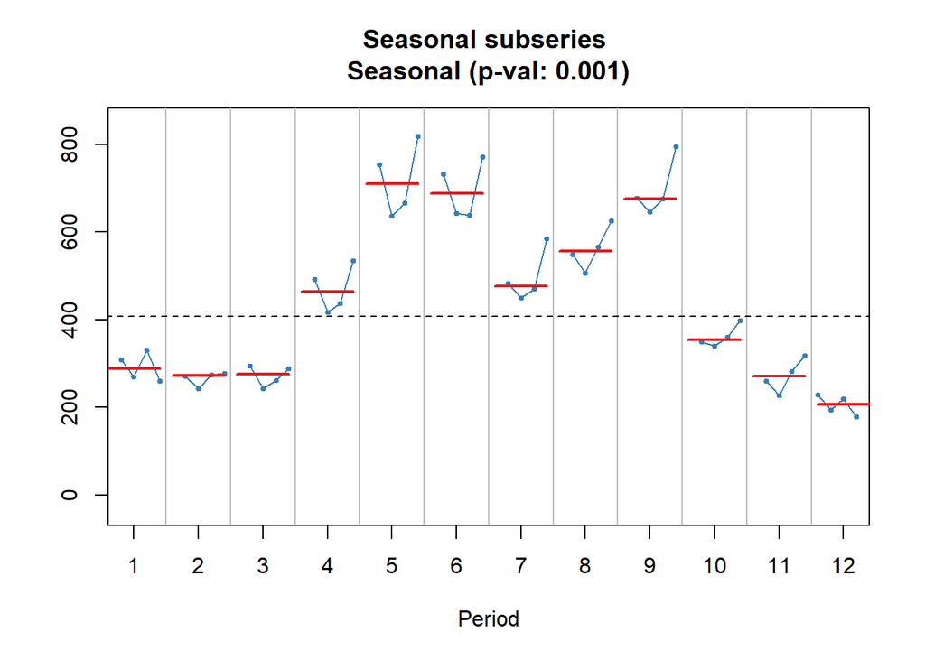

```
## Results of statistical testing
## Evidence of trend: FALSE  (pval: 0.419)
## Evidence of seasonality: TRUE  (pval: 0.001)
```

```r
seasplot(y.trn,outplot=3)
```

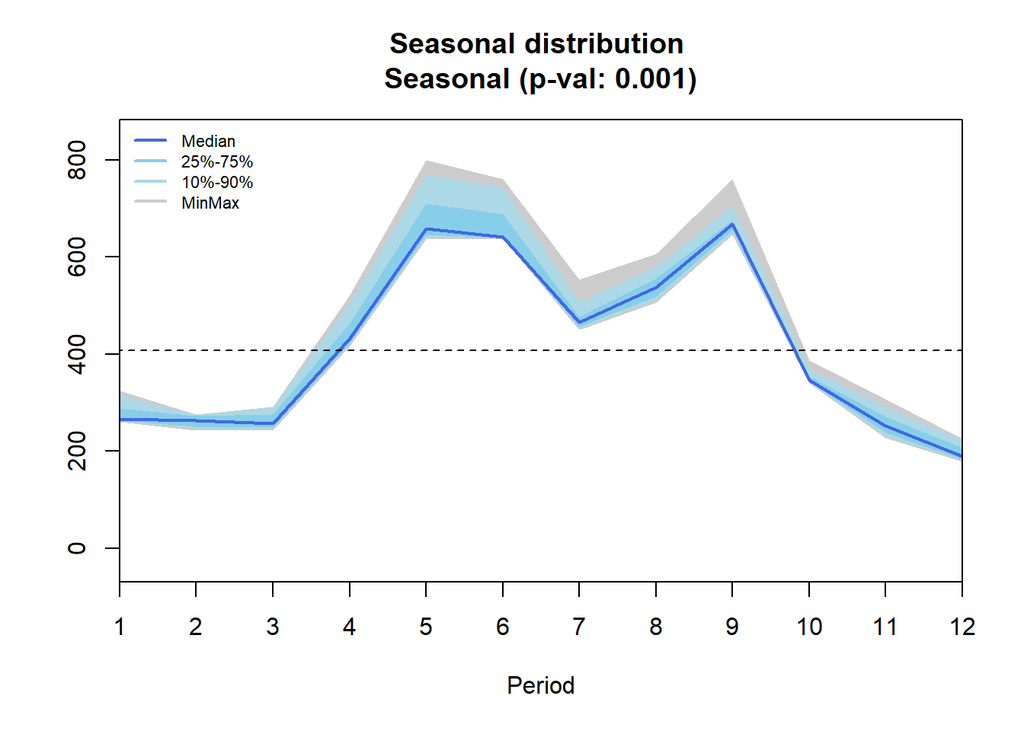

```
## Results of statistical testing
## Evidence of trend: FALSE  (pval: 0.419)
## Evidence of seasonality: TRUE  (pval: 0.001)
```

```r
seasplot(y.trn,outplot=4)
```

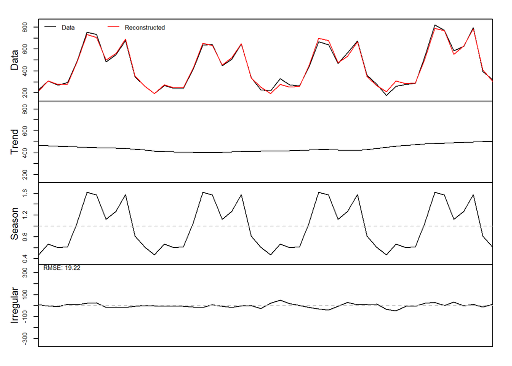

```r
dc <- decomp(y.trn,outplot=1)
```

#### Observation

- **Trend Analysis:** Both the static analysis and visual examination do not show any evidence of a trend in the data. There is no discernible trend statically or visually.
- **Seasonality Assessment:** Conversely, both the static analysis and visual inspection confirm the presence of seasonality within the dataset, with clear recurring patterns evident both statistically and visually.
- **Conclusion:** In summary, the dataset reveals the presence of seasonality while lacking a discernible trend within the time series data.

### TrendSeason - Time Series

#### Load Data

```r
y <- Y[,8]
print(y)
```

```
##  [1] 284 277 317 313 318 374 413 405 355 306 271 306 315 301 356 348 355 422 465
## [20] 467 404 347 305 336 340 318 362 348 363 435 491 505 404 359 310 337 360 342
## [39] 406 396 420 472 548 559 463 407 362 405 417 391 419 461 472 535 622 606 508
## [58] 461 390 432
```

```r
y <- ts(y,frequency=12,end=c(2018,11))
print(y)
```

```
##      Jan Feb Mar Apr May Jun Jul Aug Sep Oct Nov Dec
## 2013                                             284
## 2014 277 317 313 318 374 413 405 355 306 271 306 315
## 2015 301 356 348 355 422 465 467 404 347 305 336 340
## 2016 318 362 348 363 435 491 505 404 359 310 337 360
## 2017 342 406 396 420 472 548 559 463 407 362 405 417
## 2018 391 419 461 472 535 622 606 508 461 390 432
```

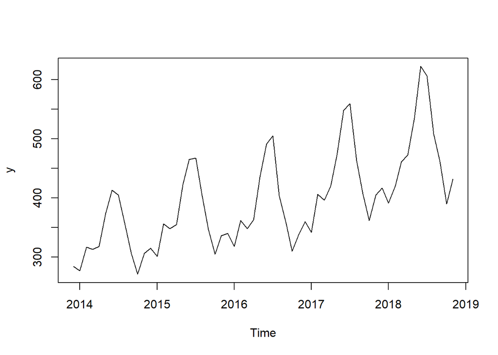

```r
plot(y)
```

#### Constructing estimation and hold-out sets

```r
y.tst <- tail(y,12)
y.trn <- head(y,48)
```

#### Exploration

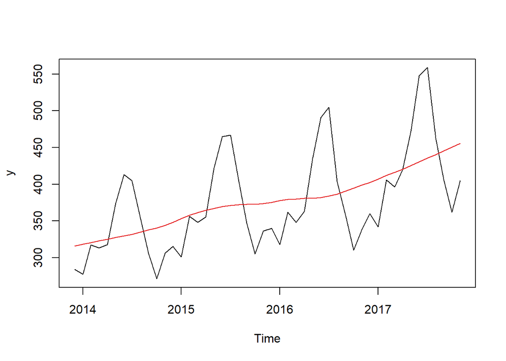

```r
cma <- cmav(y.trn,outplot=1)
```

```r
print(cma)
```

```
##           Jan      Feb      Mar      Apr      May      Jun      Jul      Aug
## 2013
## 2014 318.0834 320.3750 322.6667 324.9583 327.2500 329.5417 331.8333 334.4583
## 2015 353.0000 357.6250 361.3750 364.5000 367.1667 369.4583 371.2083 372.1667
## 2016 377.9167 379.5000 380.0000 380.7083 380.9583 381.8333 383.6667 386.5000
## 2017 407.1667 411.8750 416.3333 420.5000 425.5000 430.4998 435.4997 440.4996
##           Sep      Oct      Nov      Dec
## 2013                            315.7917
## 2014 337.5417 340.5417 344.0833 348.2500
## 2015 372.4167 372.7500 373.6250 375.2500
## 2016 390.3333 394.7083 398.6250 402.5417
## 2017 445.4995 450.4994 455.4992
```

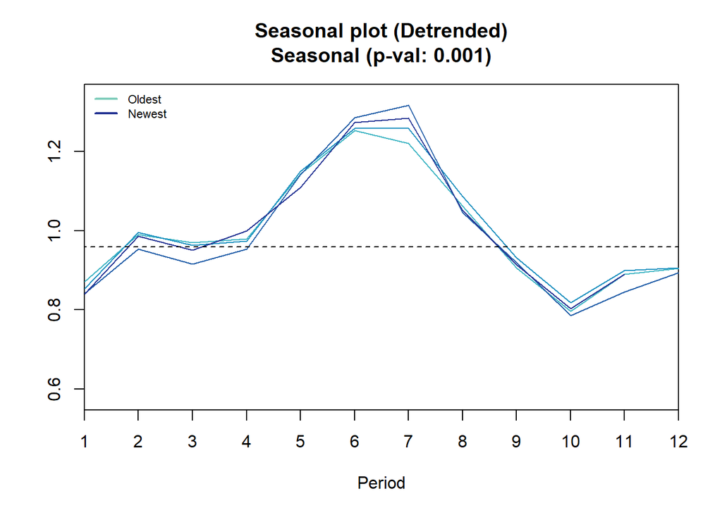

```
## Results of statistical testing
## Evidence of trend: TRUE  (pval: 0)
## Evidence of seasonality: TRUE  (pval: 0.001)
```

```r
seasplot(y.trn)
```

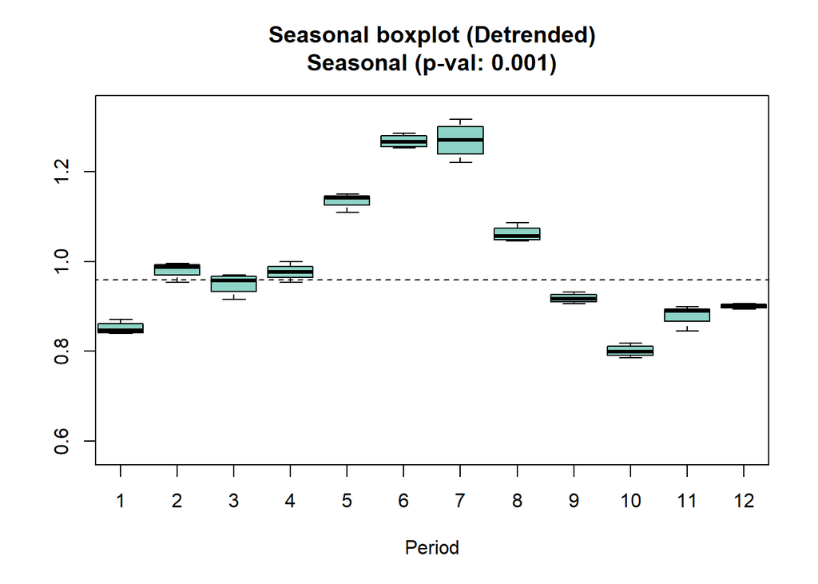

```
## Results of statistical testing
## Evidence of trend: TRUE  (pval: 0)
## Evidence of seasonality: TRUE  (pval: 0.001)
```

```r
seasplot(y.trn,outplot=2)
```

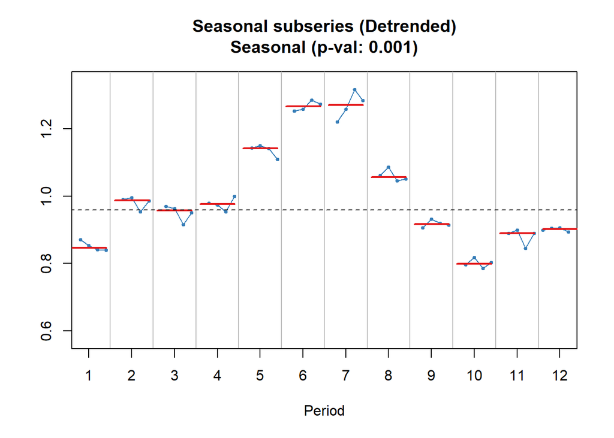

```
## Results of statistical testing
## Evidence of trend: TRUE  (pval: 0)
## Evidence of seasonality: TRUE  (pval: 0.001)
```

```r
seasplot(y.trn,outplot=3)
```

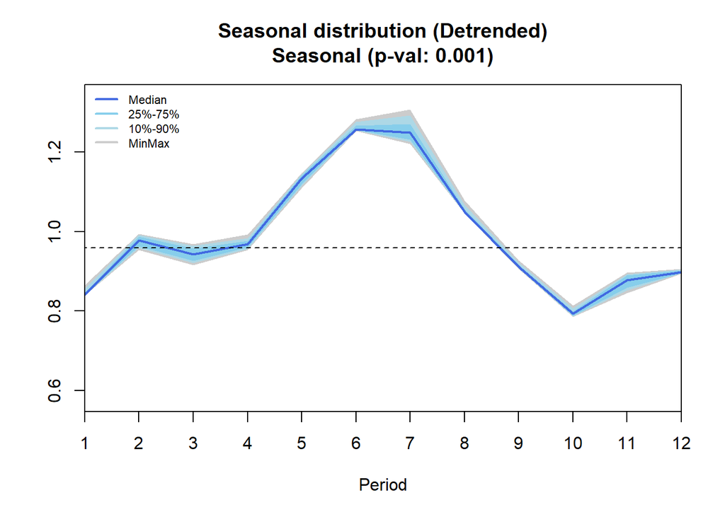

```
## Results of statistical testing
## Evidence of trend: TRUE  (pval: 0)
## Evidence of seasonality: TRUE  (pval: 0.001)
```

```r
seasplot(y.trn,outplot=4)
```

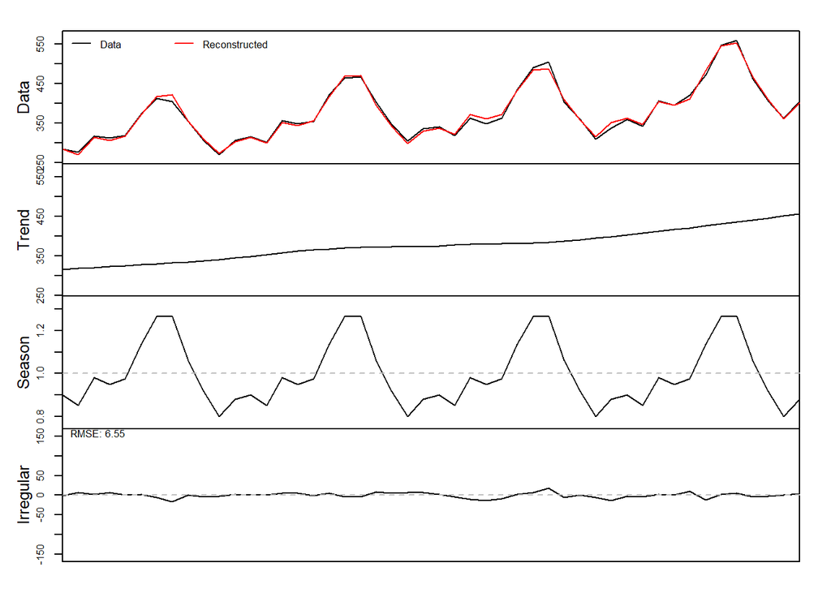

```r
dc <- decomp(y.trn,outplot=1)
```

#### Observation

**Trend Analysis:** Both the static analysis and visual examination reveal the presence of a discernible trend in the data, with clear evidence of a trend both statistically and visually.

**Seasonality Assessment:** Similarly, both the static analysis and visual inspection confirm the presence of seasonality within the dataset, with recurring patterns evident both statistically and visually.

**Conclusion:** In conclusion, the dataset unmistakably demonstrates the presence of both a discernible trend and seasonality, indicating significant temporal patterns within the time series data.

### Does your understanding of the plots agree with the underlying model?

Upon careful examination of the provided time series analyses, it is evident that there may be occasional disparities in the interpretation of trends and seasonality between the statistical results derived from the model and the visual examination.

While the model provides a statistical perspective, the visual examination offers an additional layer of insight. These differences in interpretation are duly recognized, and the conclusions drawn in each analysis take into consideration both the statistical results and the visual evidence presented in the plots.

In response to the question, it can be stated that there is a degree of agreement between the understanding derived from the plots and the underlying model’s analysis. However, it is also important to acknowledge that the agreement is not absolute, and the conclusions consider the insights from both sources to provide a comprehensive assessment of the data’s trends and seasonality.

### Does decomp() know when to remove the trend or the seasonality?

The decomp()function, as with similar decomposition methods, doesn’t make automatic decisions about removing trend or seasonality. Users need to specify the decomposition method and choose whether to keep or eliminate these components based on their specific analysis goals and the nature of the data they are working with.

### AirPassengers - Time Series

#### Load Data

```r
y <- AirPassengers
print(y)
```

```
##      Jan Feb Mar Apr May Jun Jul Aug Sep Oct Nov Dec
## 1949 112 118 132 129 121 135 148 148 136 119 104 118
## 1950 115 126 141 135 125 149 170 170 158 133 114 140
## 1951 145 150 178 163 172 178 199 199 184 162 146 166
## 1952 171 180 193 181 183 218 230 242 209 191 172 194
## 1953 196 196 236 235 229 243 264 272 237 211 180 201
## 1954 204 188 235 227 234 264 302 293 259 229 203 229
## 1955 242 233 267 269 270 315 364 347 312 274 237 278
## 1956 284 277 317 313 318 374 413 405 355 306 271 306
## 1957 315 301 356 348 355 422 465 467 404 347 305 336
## 1958 340 318 362 348 363 435 491 505 404 359 310 337
## 1959 360 342 406 396 420 472 548 559 463 407 362 405
## 1960 417 391 419 461 472 535 622 606 508 461 390 432
```

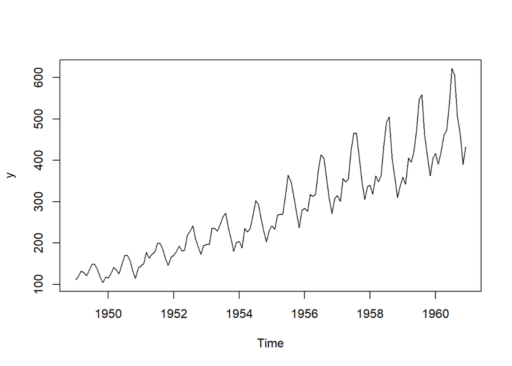

```r
plot(y)
```

#### Constructing estimation and hold-out sets

```r
y.tst <- tail(y,29)
y.trn <- head(y,115)
```

#### Exploration

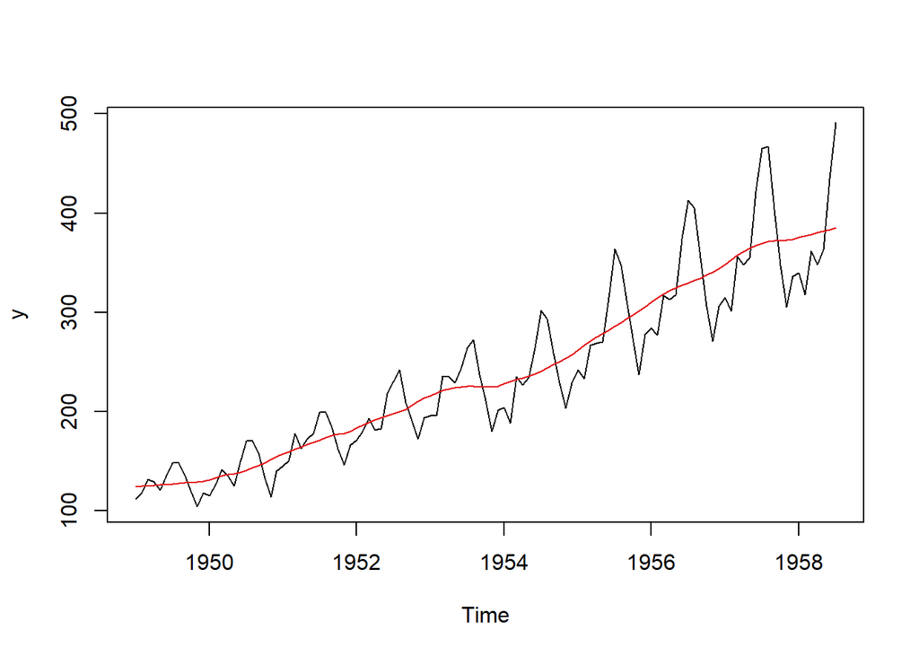

```r
cma <- cmav(y.trn,outplot=1)
```

```r
print(cma)
```

```
##           Jan      Feb      Mar      Apr      May      Jun      Jul      Aug
## 1949 124.0414 124.4998 124.9582 125.4165 125.8749 126.3333 126.7917 127.2500
## 1950 131.2500 133.0833 134.9167 136.4167 137.4167 138.7500 140.9167 143.1667
## 1951 157.1250 159.5417 161.8333 164.1250 166.6667 169.0833 171.2500 173.5833
## 1952 183.1250 186.2083 189.0417 191.2917 193.5833 195.8333 198.0417 199.7500
## 1953 215.8333 218.5000 220.9167 222.9167 224.0833 224.7083 225.3333 225.3333
## 1954 228.0000 230.4583 232.2500 233.9167 235.6250 237.7500 240.5000 243.9583
## 1955 261.8333 266.6667 271.1250 275.2083 278.5000 281.9583 285.7500 289.3333
## 1956 309.9583 314.4167 318.6250 321.7500 324.5000 327.0833 329.5417 331.8333
## 1957 348.2500 353.0000 357.6250 361.3750 364.5000 367.1667 369.4583 371.2083
## 1958 375.2500 376.8749 378.4999 380.1249 381.7498 383.3748 384.9998
##           Sep      Oct      Nov      Dec
## 1949 127.9583 128.5833 129.0000 129.7500
## 1950 145.7083 148.4167 151.5417 154.7083
## 1951 175.4583 176.8333 178.0417 180.1667
## 1952 202.2083 206.2500 210.4167 213.3750
## 1953 224.9583 224.5833 224.4583 225.5417
## 1954 247.1667 250.2500 253.5000 257.1250
## 1955 293.2500 297.1667 301.0000 305.4583
## 1956 334.4583 337.5417 340.5417 344.0833
## 1957 372.1667 372.4167 372.7500 373.6250
## 1958
```

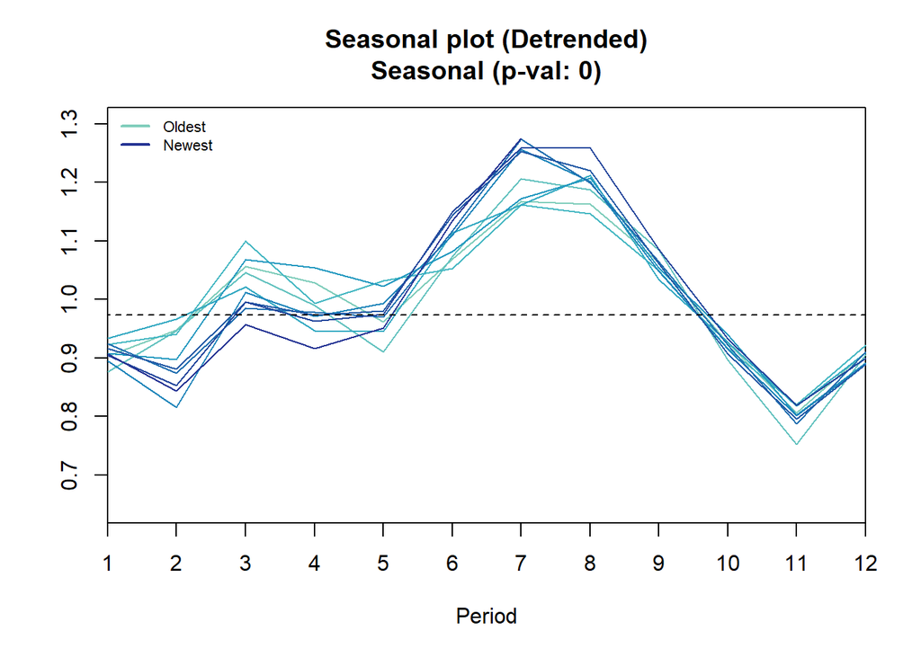

```
## Results of statistical testing
## Evidence of trend: TRUE  (pval: 0)
## Evidence of seasonality: TRUE  (pval: 0)
```

```r
seasplot(y.trn)
```

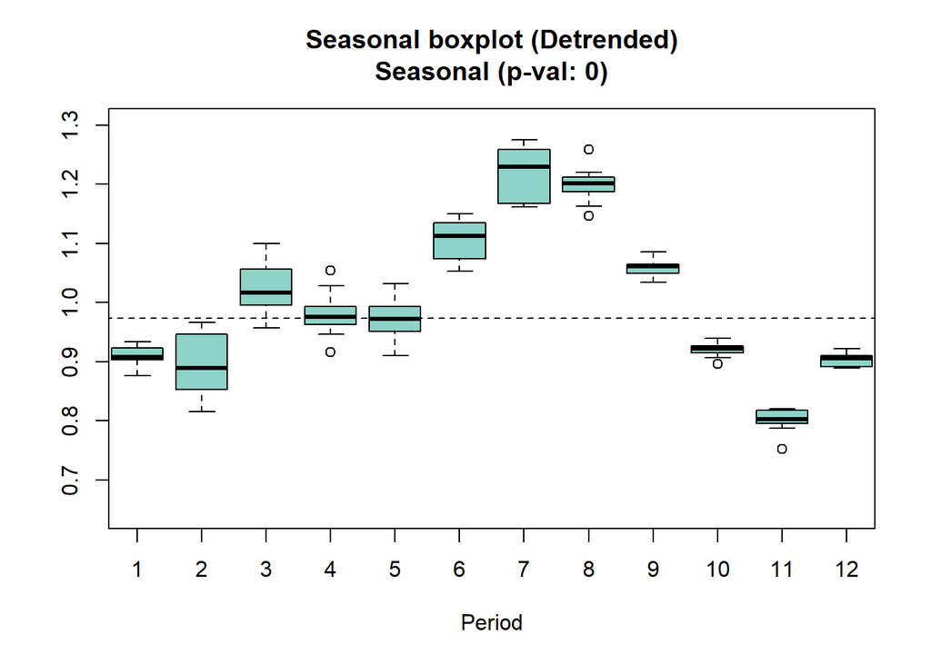

```
## Results of statistical testing
## Evidence of trend: TRUE  (pval: 0)
## Evidence of seasonality: TRUE  (pval: 0)
```

```r
seasplot(y.trn,outplot=2)
```

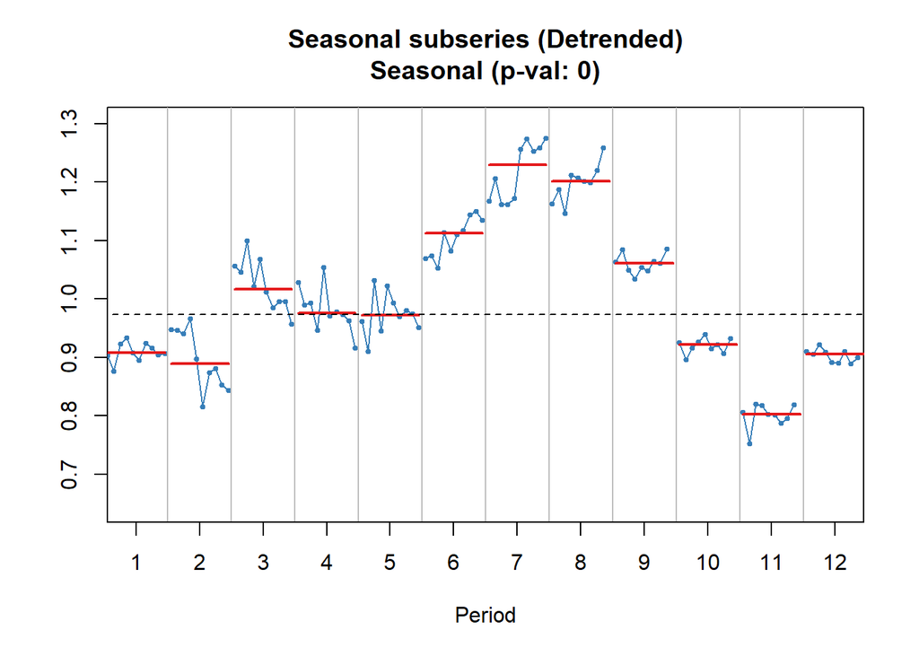

```
## Results of statistical testing
## Evidence of trend: TRUE  (pval: 0)
## Evidence of seasonality: TRUE  (pval: 0)
```

```r
seasplot(y.trn,outplot=3)
```

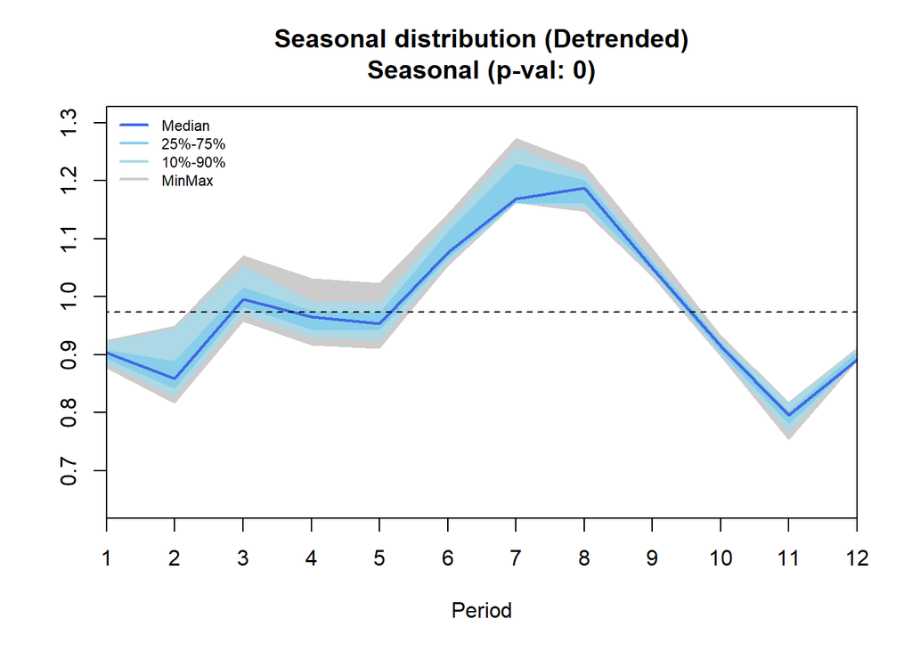

```
## Results of statistical testing
## Evidence of trend: TRUE  (pval: 0)
## Evidence of seasonality: TRUE  (pval: 0)
```

```r
seasplot(y.trn,outplot=4)
```

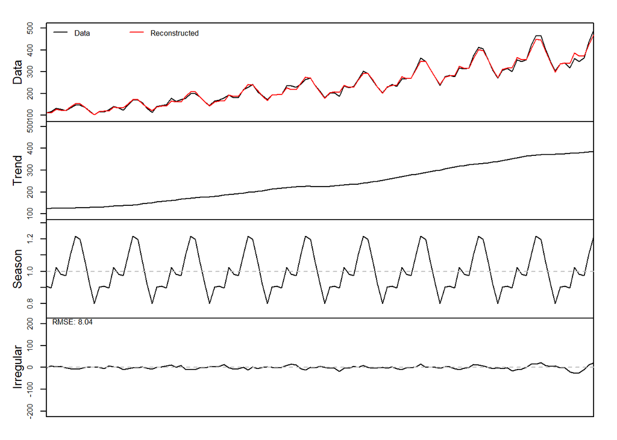

```r
dc <- decomp(y.trn,outplot=1)
```

#### Observation

- **Trend Analysis:** Both the static analysis and visual examination distinctly indicate the presence of an additive trend in the data, with clear evidence of a trend both statistically and visually.
- **Seasonality Assessment:** Similarly, both the static analysis and visual inspection consistently confirm the presence of seasonality within the dataset, with recurring patterns evident both statistically and visually.
- **Conclusion:** In summary, the data unequivocally exhibits both a discernible additive trend and seasonality, as supported by both static analysis and visual examination of this time series data.